# Genetic Risk Score

Date: 2021_03_22

Analyzed by: Sara Saez Atienzar

## Background

Genetic risk score analysis can be used to identify shared genetic etiology between two different disease.

### Pipeline

Genetic risk score analysis uses the following sofwares/packages (and versions) R 4.0.3 plink 1.9 meta

## Directory and organization

```python
%%bash
pwd
#mkdir GRS
cd GRS
#mkdir Plots
#mkdir Results
#mkdir Data
#mkdir Scripts
#mkdir Swarms
#mkdir Swarms_oe
mkdir Bin
rm bin
ls
```

```
/data/ALS_50k/SaraSaez_ALS/2021-03-18.COLABORATION_MG
bin
Bin
Data
Plots
Results
Scripts
Swarms
Swarms_oe
```

```
rm: cannot remove ‘bin’: Is a directory
```

## Analysis

### Extract instruments

I will use the instrument of MR to calculate GRS. First, I extract the instruments of each significant trait

```python
%%bash

cd /data/ALS_50k/SaraSaez_ALS/2021-03-18.COLABORATION_MG/GRS/Data

module load R/4.0.3
R --vanilla --no-save

library(data.table)
library(TwoSampleMR)
#install.packages("MRinstruments")
library(MRInstruments)
#install.packages("WSpiller/RadialMR")
library("RadialMR")
library("ieugwasr")
library("dplyr")
library("tidyverse")
sessionInfo()

# extract the instruments from SMR

#the token will be different each time, it needs to be prepare at the moment
token <- "ya29.a0AfH6SMAYloNpa7fqlbyIgGtg6CMhB9iZ1dFEnj381EL59MlGla-OrK984t_wAhTaXtPCve5H5Am9yJydQxkNcfAkAowcqB1WZ5ETDjW06d6N9OJINbdkhqH2xEXJlxLAaU_PY4Pp7JavWeX23fKj8QEQ0FFqUw"

# choose the GWAS

##### ebiGCST005531

ebiGCST005531 = extract_instruments("ebi-a-GCST005531", p1 = 5e-08, clump = TRUE, p2 = 5e-08,
                                  r2 = 0.001, kb = 10000, access_token = token,
                                 force_server = TRUE)
ebiGCST005531
dim(ebiGCST005531)

MGtemp = fread("/data/NDRS_LNG/MyastheniaGravis/updated.April2020/MetaAnalysis.hg38.ByCohort.rerun/USmerged.Itals.hg38/META_MG.USmerged.Itals.UNRELATED.hg38.Rsq03.glm_filteredDirection.HetISq80MAF001cases.rsid.txt", header = T)

head(MGtemp)
MGtemp$SNP = MGtemp$rsID
MGtemp$Freq1 = MGtemp$maf_EA.CASE
MGtemp$effect_allele = MGtemp$EffectAllele
MGtemp$other_allele = MGtemp$OtherAllele
MGtemp$Beta = MGtemp$beta
MGtemp$P.value = MGtemp$P

Out_data = format_data(MGtemp,type="outcome", beta_col = "Beta", se_col = "StdErr", eaf_col = "Freq1", pval_col = "P.value")
head(Out_data)
dat <- harmonise_data(exposure_dat=ebiGCST005531, outcome_dat=Out_data, action=2)
head(dat)
dim(dat)
data2 = select(dat, SNP, effect_allele.exposure, other_allele.exposure, beta.exposure)
write.table(data2,"ebiGCST005531_toscore.tab", quote = F, sep = " ", row.names=F)

##### ebiGCST002318

ebiGCST002318 = extract_instruments("ebi-a-GCST002318", p1 = 5e-08, clump = TRUE, p2 = 5e-08,
                                  r2 = 0.001, kb = 10000, access_token = token,
                                 force_server = TRUE)
ebiGCST002318
dim(ebiGCST002318)



Out_data = format_data(MGtemp,type="outcome", beta_col = "Beta", se_col = "StdErr", eaf_col = "Freq1", pval_col = "P.value")
head(Out_data)
dat <- harmonise_data(exposure_dat= ebiGCST002318, outcome_dat=Out_data, action=2)
head(dat)
dim(dat)
data2 = select(dat, SNP, effect_allele.exposure, other_allele.exposure, beta.exposure)
write.table(data2,"ebiGCST002318_toscore.tab", quote = F, sep = " ", row.names=F)


######## ebi-a-GCST005536

ebiGCST005536 = extract_instruments("ebi-a-GCST005536", p1 = 5e-08, clump = TRUE, p2 = 5e-08,
                                  r2 = 0.001, kb = 10000, access_token = token,
                                 force_server = TRUE)
ebiGCST005536
dim(ebiGCST005536)



Out_data = format_data(MGtemp,type="outcome", beta_col = "Beta", se_col = "StdErr", eaf_col = "Freq1", pval_col = "P.value")
head(Out_data)
dat <- harmonise_data(exposure_dat= ebiGCST005536, outcome_dat=Out_data, action=2)
head(dat)
dim(dat)
data2 = select(dat, SNP, effect_allele.exposure, other_allele.exposure, beta.exposure)
write.table(data2,"ebiGCST005536_toscore.tab", quote = F, sep = " ", row.names=F)

######### ukb-a-77

ukba77 = extract_instruments("ukb-a-77", p1 = 5e-08, clump = TRUE, p2 = 5e-08,
                                  r2 = 0.001, kb = 10000, access_token = token,
                                 force_server = TRUE)
ukba77
dim(ukba77)



Out_data = format_data(MGtemp,type="outcome", beta_col = "Beta", se_col = "StdErr", eaf_col = "Freq1", pval_col = "P.value")
head(Out_data)
dat <- harmonise_data(exposure_dat=ukba77, outcome_dat=Out_data, action=2)
head(dat)
dim(dat)
data2 = select(dat, SNP, effect_allele.exposure, other_allele.exposure, beta.exposure)
write.table(data2,"ukba77_toscore.tab", quote = F, sep = " ", row.names=F)

##########ukb-a-190

ukba190 = extract_instruments("ukb-a-190", p1 = 5e-08, clump = TRUE, p2 = 5e-08,
                                  r2 = 0.001, kb = 10000, access_token = token,
                                 force_server = TRUE)
ukba190
dim(ukba190)



Out_data = format_data(MGtemp,type="outcome", beta_col = "Beta", se_col = "StdErr", eaf_col = "Freq1", pval_col = "P.value")
head(Out_data)
dat <- harmonise_data(exposure_dat=ukba190, outcome_dat=Out_data, action=2)
head(dat)
dim(dat)
data2 = select(dat, SNP, effect_allele.exposure, other_allele.exposure, beta.exposure)
write.table(data2,"ukba190_toscore.tab", quote = F, sep = " ", row.names=F)
```

```
R version 4.0.3 (2020-10-10) -- "Bunny-Wunnies Freak Out"
Copyright (C) 2020 The R Foundation for Statistical Computing
Platform: x86_64-pc-linux-gnu (64-bit)

R is free software and comes with ABSOLUTELY NO WARRANTY.
You are welcome to redistribute it under certain conditions.
Type 'license()' or 'licence()' for distribution details.

  Natural language support but running in an English locale

R is a collaborative project with many contributors.
Type 'contributors()' for more information and
'citation()' on how to cite R or R packages in publications.

Type 'demo()' for some demos, 'help()' for on-line help, or
```

[output cut: 1880 more lines]

[output not shown]

[output cut: 418 more lines]

[output not shown]

### Formatting

I need to format the instruments to have the same format that plink binary files

```python
%%bash
head /data/NDRS_LNG/MyastheniaGravis/updated.April2020/US/Imputation.USmerged.hg38/plinkForPRS/USmerged.UNRELATED.Imputed.pass.Rsq03MAF00001.chr8.bim
head /data/ALS_50k/SaraSaez_ALS/2021-03-18.COLABORATION_MG/GRS/Data/ebiGCST005531_toscore.tab
head /data/NDRS_LNG/MyastheniaGravis/updated.April2020/MetaAnalysis.hg38.ByCohort.rerun/USmerged.Itals.hg38/META_MG.USmerged.Itals.UNRELATED.hg38.Rsq03.glm_filteredDirection.HetISq80MAF001cases.rsid.txt
```

```
8	chr8:60165:TCAC:T	0	60165	T	TCAC
8	chr8:60196:CAG:C	0	60196	C	CAG
8	chr8:60199:ACT:A	0	60199	A	ACT
8	chr8:60358:CA:C	0	60358	C	CA
8	chr8:60631:C:A	0	60631	A	C
8	chr8:60641:GGAATGTT:G	0	60641	G	GGAATGTT
8	chr8:60702:TTGA:T	0	60702	T	TTGA
8	chr8:60708:ATT:A	0	60708	A	ATT
8	chr8:61524:T:C	0	61524	C	T
8	chr8:62246:C:T	0	62246	T	C
SNP effect_allele.exposure other_allele.exposure beta.exposure
rs1014486 C T 0.10075
rs1021156 C T -0.115113
rs10420809 T C 0.121377
rs1077667 T C -0.15187
rs10892299 T C -0.115074
rs11052877 G A 0.0998453
rs11154801 A C 0.102557
rs11172342 T G -0.121377
rs11554159 A G -0.141448
MarkerName	CHROM	POS	OtherAllele	EffectAllele	maf_EA.CASE	maf_EA.CTRL	beta	StdErr	P	Direction	HetISq	rsID
1:722408:C:G	1	722408	C	G	0.163107314468767	0.154880395930712	0.0594	0.0495	0.2299	-+	68.7	rs75935175
1:722700:G:A	1	722700	G	A	0.0130806193272824	0.0173907066263404	-0.215	0.1581	0.174	--	0	rs1415481957
1:727233:G:A	1	727233	G	A	0.0109450080085424	0.0152048391531482	-0.0362	0.1687	0.8299	+-	0	rs151190501
1:727242:G:A	1	727242	G	A	0.0816871329418046	0.0943497387957107	0.1044	0.0661	0.114	++	0	rs61769339
1:727717:C:G	1	727717	C	G	0.144687666844634	0.132293098707726	0.1063	0.0522	0.04161	--	50.8	rs61769340
1:758351:A:G	1	758351	A	G	0.0806193272824346	0.0945971954907891	0.1025	0.0663	0.1221	--	0	rs12238997
1:758443:G:C	1	758443	G	C	0.0822210357714896	0.0953120703876821	0.1035	0.0658	0.1158	++	0	rs61769351
1:769257:G:A	1	769257	G	A	0.0344367325146823	0.036967280725873	0.074	0.0991	0.4551	+-	0	rs142559957
1:783125:G:A	1	783125	G	A	0.0266951414842499	0.0252130877096508	0.1875	0.1151	0.1033	++	0	rs181440659
```

```python
%%bash

cd /data/ALS_50k/SaraSaez_ALS/2021-03-18.COLABORATION_MG/GRS/Data

module load R/4.0.3
R --vanilla --no-save

# Load libraries
library(data.table)
library(tidyverse)
library(dplyr)
gwas = fread("/data/NDRS_LNG/MyastheniaGravis/updated.April2020/MetaAnalysis.hg38.ByCohort.rerun/USmerged.Itals.hg38/META_MG.USmerged.Itals.UNRELATED.hg38.Rsq03.glm_filteredDirection.HetISq80MAF001cases.rsid.txt", header = T)
score = fread("/data/ALS_50k/SaraSaez_ALS/2021-03-18.COLABORATION_MG/GRS/Data/ebiGCST005531_toscore.tab", header =T)
score$rsID = score$SNP


merged = merge(gwas, score, by ="rsID")
head(merged)

#genereta the variant name based on the position and allele
merged$chr = "chr"
merged$chrnm1 = paste(merged$chr, merged$CHROM, sep="")
merged$chrnm = paste(merged$chrnm1, merged$POS, sep = ":")
merged$A1 = paste(merged$effect_allele.exposure, merged$other_allele.exposure, sep =":")
merged$A2 = paste(merged$other_allele.exposure, merged$effect_allele.exposure, sep =":")
merged$marker1 = paste(merged$chrnm, merged$A1, sep = ":")
merged$marker2 = paste(merged$chrnm, merged$A2, sep = ":")
datafile1 = select(merged, marker1,effect_allele.exposure, beta.exposure)
datafile2 = select(merged, marker2,effect_allele.exposure, beta.exposure)
names(datafile2)[names(datafile2) == "marker2"] <- "marker1"
datafile <- rbind(datafile1,datafile2)
head(datafile)
print(datafile)

write.table(datafile,"ebiGCST005531_toscore.hg38.tab", quote = F, sep = " ", row.names = F)
write.table(datafile,"ebiGCST005531_toscore.hg38.noheader.tab", quote = F, sep = " ", col.names=F, row.names = F)



score = fread("/data/ALS_50k/SaraSaez_ALS/2021-03-18.COLABORATION_MG/GRS/Data/ebiGCST002318_toscore.tab", header =T)
score$rsID = score$SNP


merged = merge(gwas, score, by ="rsID")
head(merged)

#genereta the variant name based on the position and allele
merged$chr = "chr"
merged$chrnm1 = paste(merged$chr, merged$CHROM, sep="")
merged$chrnm = paste(merged$chrnm1, merged$POS, sep = ":")
merged$A1 = paste(merged$effect_allele.exposure, merged$other_allele.exposure, sep =":")
merged$A2 = paste(merged$other_allele.exposure, merged$effect_allele.exposure, sep =":")
merged$marker1 = paste(merged$chrnm, merged$A1, sep = ":")
merged$marker2 = paste(merged$chrnm, merged$A2, sep = ":")
datafile1 = select(merged, marker1,effect_allele.exposure, beta.exposure)
datafile2 = select(merged, marker2,effect_allele.exposure, beta.exposure)
names(datafile2)[names(datafile2) == "marker2"] <- "marker1"
datafile <- rbind(datafile1,datafile2)
head(datafile)
print(datafile)

write.table(datafile,"ebiGCST002318_toscore.hg38.tab", quote = F, sep = " ", row.names = F)
write.table(datafile,"ebiGCST002318_toscore.hg38.noheader.tab", quote = F, sep = " ", col.names=F, row.names = F)

#ebiGCST005536_toscore.tab

score = fread("/data/ALS_50k/SaraSaez_ALS/2021-03-18.COLABORATION_MG/GRS/Data/ebiGCST005536_toscore.tab", header =T)
score$rsID = score$SNP


merged = merge(gwas, score, by ="rsID")
head(merged)

#genereta the variant name based on the position and allele
merged$chr = "chr"
merged$chrnm1 = paste(merged$chr, merged$CHROM, sep="")
merged$chrnm = paste(merged$chrnm1, merged$POS, sep = ":")
merged$A1 = paste(merged$effect_allele.exposure, merged$other_allele.exposure, sep =":")
merged$A2 = paste(merged$other_allele.exposure, merged$effect_allele.exposure, sep =":")
merged$marker1 = paste(merged$chrnm, merged$A1, sep = ":")
merged$marker2 = paste(merged$chrnm, merged$A2, sep = ":")
datafile1 = select(merged, marker1,effect_allele.exposure, beta.exposure)
datafile2 = select(merged, marker2,effect_allele.exposure, beta.exposure)
names(datafile2)[names(datafile2) == "marker2"] <- "marker1"
datafile <- rbind(datafile1,datafile2)
head(datafile)
print(datafile)

write.table(datafile,"ebiGCST005536_toscore.hg38.tab", quote = F, sep = " ", row.names = F)
write.table(datafile,"ebiGCST005536_toscore.hg38.noheader.tab", quote = F, sep = " ", col.names=F, row.names = F)

#ukba77_toscore.tab

score = fread("/data/ALS_50k/SaraSaez_ALS/2021-03-18.COLABORATION_MG/GRS/Data/ukba77_toscore.tab", header =T)
score$rsID = score$SNP


merged = merge(gwas, score, by ="rsID")
head(merged)

#genereta the variant name based on the position and allele
merged$chr = "chr"
merged$chrnm1 = paste(merged$chr, merged$CHROM, sep="")
merged$chrnm = paste(merged$chrnm1, merged$POS, sep = ":")
merged$A1 = paste(merged$effect_allele.exposure, merged$other_allele.exposure, sep =":")
merged$A2 = paste(merged$other_allele.exposure, merged$effect_allele.exposure, sep =":")
merged$marker1 = paste(merged$chrnm, merged$A1, sep = ":")
merged$marker2 = paste(merged$chrnm, merged$A2, sep = ":")
datafile1 = select(merged, marker1,effect_allele.exposure, beta.exposure)
datafile2 = select(merged, marker2,effect_allele.exposure, beta.exposure)
names(datafile2)[names(datafile2) == "marker2"] <- "marker1"
datafile <- rbind(datafile1,datafile2)
head(datafile)
print(datafile)

write.table(datafile,"ukba77_toscore.hg38.tab", quote = F, sep = " ", row.names = F)
write.table(datafile,"ukba77_toscore.hg38.noheader.tab", quote = F, sep = " ", col.names=F, row.names = F)

#ukba190_toscore.tab


score = fread("/data/ALS_50k/SaraSaez_ALS/2021-03-18.COLABORATION_MG/GRS/Data/ukba190_toscore.tab", header =T)
score$rsID = score$SNP


merged = merge(gwas, score, by ="rsID")
head(merged)

#genereta the variant name based on the position and allele
merged$chr = "chr"
merged$chrnm1 = paste(merged$chr, merged$CHROM, sep="")
merged$chrnm = paste(merged$chrnm1, merged$POS, sep = ":")
merged$A1 = paste(merged$effect_allele.exposure, merged$other_allele.exposure, sep =":")
merged$A2 = paste(merged$other_allele.exposure, merged$effect_allele.exposure, sep =":")
merged$marker1 = paste(merged$chrnm, merged$A1, sep = ":")
merged$marker2 = paste(merged$chrnm, merged$A2, sep = ":")
datafile1 = select(merged, marker1,effect_allele.exposure, beta.exposure)
datafile2 = select(merged, marker2,effect_allele.exposure, beta.exposure)
names(datafile2)[names(datafile2) == "marker2"] <- "marker1"
datafile <- rbind(datafile1,datafile2)
head(datafile)
print(datafile)

write.table(datafile,"ukba190_toscore.hg38.tab", quote = F, sep = " ", row.names = F)
write.table(datafile,"ukba190_toscore.hg38.noheader.tab", quote = F, sep = " ", col.names=F, row.names = F)
```

```
R version 4.0.3 (2020-10-10) -- "Bunny-Wunnies Freak Out"
Copyright (C) 2020 The R Foundation for Statistical Computing
Platform: x86_64-pc-linux-gnu (64-bit)

R is free software and comes with ABSOLUTELY NO WARRANTY.
You are welcome to redistribute it under certain conditions.
Type 'license()' or 'licence()' for distribution details.

  Natural language support but running in an English locale

R is a collaborative project with many contributors.
Type 'contributors()' for more information and
'citation()' on how to cite R or R packages in publications.

Type 'demo()' for some demos, 'help()' for on-line help, or
'help.start()' for an HTML browser interface to help.
Type 'q()' to quit R.

>
> # Load libraries
> library(data.table)
> library(tidyverse)
> library(dplyr)
> gwas = fread("/data/NDRS_LNG/MyastheniaGravis/updated.April2020/MetaAnalysis.hg38.ByCohort.rerun/USmerged.Itals.hg38/META_MG.USmerged.Itals.UNRELATED.hg38.Rsq03.glm_filteredDirection.HetISq80MAF001cases.rsid.txt", header = T)
> score = fread("/data/ALS_50k/SaraSaez_ALS/2021-03-18.COLABORATION_MG/GRS/Data/ebiGCST005531_toscore.tab", header =T)
> score$rsID = score$SNP
>
>
> merged = merge(gwas, score, by ="rsID")
> head(merged)
         rsID       MarkerName CHROM       POS OtherAllele EffectAllele
1:  rs1014486  3:159973324:T:C     3 159973324           T            C
2:  rs1021156   8:78663569:C:T     8  78663569           C            T
3: rs10420809  19:10616338:T:C    19  10616338           T            C
4:  rs1077667   19:6668961:C:T    19   6668961           C            T
5: rs10892299 11:118856134:C:T    11 118856134           C            T
6: rs11052877   12:9753094:A:G    12   9753094           A            G
   maf_EA.CASE maf_EA.CTRL    beta StdErr      P Direction HetISq        SNP
1:   0.4676989   0.4401842  0.0267 0.0367 0.4676        +-   61.4  rs1014486
2:   0.3080619   0.2767666  0.0049 0.0402 0.9039        -+    0.0  rs1021156
```

[output cut: 515 more lines]

```
87:  chr4:148712269:C:T                      T   -0.00484565
88:  chr6:148206662:T:C                      C    0.00280772
89:  chr8:132920573:A:G                      G   -0.00297126
90:   chr6:31262940:T:A                      A   -0.00758943
91:   chr6:31296615:G:A                      A   -0.00417149
92:   chr6:34825347:G:A                      A    0.00275516
93:   chr9:21553642:G:C                      C   -0.00309753
94:  chr3:188397894:C:A                      A   -0.00537480
                marker1 effect_allele.exposure beta.exposure
>
> write.table(datafile,"ukba190_toscore.hg38.tab", quote = F, sep = " ", row.names = F)
> write.table(datafile,"ukba190_toscore.hg38.noheader.tab", quote = F, sep = " ", col.names=F, row.names = F)
>
>
>
```

[output not shown]

### US COHORT ANALYSIS

#### Merge chromosomes

From terminal

```python
%%bash
cd /data/NDRS_LNG/MyastheniaGravis/updated.April2020/US/Imputation.USmerged.hg38/plinkForPRS/
module load plink/1.9.0-beta4.4
plink --bfile USmerged.UNRELATED.Imputed.pass.Rsq03MAF00001.chr1 --merge-list mylist.txt --allow-no-sex --make-bed --out /data/ALS_50k/SaraSaez_ALS/2021-03-18.COLABORATION_MG/GRS/Bin/MG.USmerged.UNRELATED.Imputed.ALL
```

```
Process is interrupted.
```

#### Filter chromosomes

```python
%%bash
cd /data/ALS_50k/SaraSaez_ALS/2021-03-18.COLABORATION_MG/GRS/Bin/
module load plink/1.9.0-beta4.4
plink \
--bfile MG.USmerged.UNRELATED.Imputed.ALL \
--maf 0.01 \
--geno 0.15 \
--make-bed \
--out MG.USmerged.UNRELATED.Imputed.maf0.01.geno0.15.ALL
```

```
PLINK v1.90b4.4 64-bit (21 May 2017)           www.cog-genomics.org/plink/1.9/
(C) 2005-2017 Shaun Purcell, Christopher Chang   GNU General Public License v3
Logging to MG.USmerged.UNRELATED.Imputed.maf0.01.geno0.15.ALL.log.
Options in effect:
  --bfile MG.USmerged.UNRELATED.Imputed.ALL
  --geno 0.15
  --maf 0.01
  --make-bed
  --out MG.USmerged.UNRELATED.Imputed.maf0.01.geno0.15.ALL

386449 MB RAM detected; reserving 193224 MB for main workspace.
32911787 variants loaded from .bim file.
36088 people (0 males, 0 females, 36088 ambiguous) loaded from .fam.
Ambiguous sex IDs written to
MG.USmerged.UNRELATED.Imputed.maf0.01.geno0.15.ALL.nosex .
36088 phenotype values loaded from .fam.
Using 1 thread (no multithreaded calculations invoked).
Before main variant filters, 36088 founders and 0 nonfounders present.
Calculating allele frequencies... 0%1%2%3%4%5%6%7%8%9%10%11%12%13%14%15%16%17%18%19%20%21%22%23%24%25%26%27%28%29%30%31%32%33%34%35%36%37%38%39%40%41%42%43%44%45%46%47%48%49%50%51%52%53%54%55%56%57%58%59%60%61%62%63%64%65%66%67%68%69%70%71%72%73%74%75%76%77%78%79%80%81%82%83%84%85%86%87%88%89%90%91%…
0 variants removed due to missing genotype data (--geno).
24084505 variants removed due to minor allele threshold(s)
(--maf/--max-maf/--mac/--max-mac).
8827282 variants and 36088 people pass filters and QC.
Among remaining phenotypes, 964 are cases and 35124 are controls.
--make-bed to MG.USmerged.UNRELATED.Imputed.maf0.01.geno0.15.ALL.bed +
MG.USmerged.UNRELATED.Imputed.maf0.01.geno0.15.ALL.bim +
MG.USmerged.UNRELATED.Imputed.maf0.01.geno0.15.ALL.fam ... 0%1%2%3%4%5%6%7%8%9%10%11%12%13%14%15%16%17%18%19%20%21%22%23%24%25%26%27%28%29%30%31%32%33%34%35%36%37%38%39%40%41%42%43%44%45%46%47%48%49%50%51%52%53%54%55%56%57%58%59%60%61%62%63%64%65%66%67%68%69%70%71%72%73%74%75%76%77%78%79%80%81%82%83…
```

```
[+] Loading plink  1.9.0-beta4.4  on cn1003
Warning: Ignoring phenotypes of missing-sex samples.  If you don't want those
phenotypes to be ignored, use the --allow-no-sex flag.
```

#### Calculate scores

```python
%%bash
cd /data/ALS_50k/SaraSaez_ALS/2021-03-18.COLABORATION_MG/GRS/Bin/
module load plink/1.9.0-beta4.4
plink \
--bfile MG.USmerged.UNRELATED.Imputed.maf0.01.geno0.15.ALL \
--score /data/ALS_50k/SaraSaez_ALS/2021-03-18.COLABORATION_MG/GRS/Data/ebiGCST005531_toscore.hg38.noheader.tab \
--out /data/ALS_50k/SaraSaez_ALS/2021-03-18.COLABORATION_MG/GRS/Data/MG.USmerged.ebiGCST005531
```

```
PLINK v1.90b4.4 64-bit (21 May 2017)           www.cog-genomics.org/plink/1.9/
(C) 2005-2017 Shaun Purcell, Christopher Chang   GNU General Public License v3
Logging to /data/ALS_50k/SaraSaez_ALS/2021-03-18.COLABORATION_MG/GRS/Data/MG.USmerged.ebiGCST005531.log.
Options in effect:
  --bfile MG.USmerged.UNRELATED.Imputed.maf0.01.geno0.15.ALL
  --out /data/ALS_50k/SaraSaez_ALS/2021-03-18.COLABORATION_MG/GRS/Data/MG.USmerged.ebiGCST005531
  --score /data/ALS_50k/SaraSaez_ALS/2021-03-18.COLABORATION_MG/GRS/Data/ebiGCST005531_toscore.hg38.noheader.tab

386449 MB RAM detected; reserving 193224 MB for main workspace.
8827282 variants loaded from .bim file.
36088 people (0 males, 0 females, 36088 ambiguous) loaded from .fam.
Ambiguous sex IDs written to
/data/ALS_50k/SaraSaez_ALS/2021-03-18.COLABORATION_MG/GRS/Data/MG.USmerged.ebiGCST005531.nosex
.
36088 phenotype values loaded from .fam.
Using 1 thread (no multithreaded calculations invoked).
Before main variant filters, 36088 founders and 0 nonfounders present.
Calculating allele frequencies... 0%1%2%3%4%5%6%7%8%9%10%11%12%13%14%15%16%17%18%19%20%21%22%23%24%25%26%27%28%29%30%31%32%33%34%35%36%37%38%39%40%41%42%43%44%45%46%47%48%49%50%51%52%53%54%55%56%57%58%59%60%61%62%63%64%65%66%67%68%69%70%71%72%73%74%75%76%77%78%79%80%81%82%83%84%85%86%87%88%89%90%91%…
8827282 variants and 36088 people pass filters and QC.
Note: No phenotypes present.
--score: 43 valid predictors loaded.
--score: Results written to
/data/ALS_50k/SaraSaez_ALS/2021-03-18.COLABORATION_MG/GRS/Data/MG.USmerged.ebiGCST005531.profile
.
```

```
[+] Loading plink  1.9.0-beta4.4  on cn1003
Warning: Ignoring phenotypes of missing-sex samples.  If you don't want those
phenotypes to be ignored, use the --allow-no-sex flag.
Warning: 43 lines skipped in --score file (43 due to variant ID mismatch, 0 due
to allele code mismatch); see
/data/ALS_50k/SaraSaez_ALS/2021-03-18.COLABORATION_MG/GRS/Data/MG.USmerged.ebiGCST005531.nopred
for details.
```

```python
%%bash
cd /data/ALS_50k/SaraSaez_ALS/2021-03-18.COLABORATION_MG/GRS/Bin/
module load plink/1.9.0-beta4.4
plink \
--bfile MG.USmerged.UNRELATED.Imputed.maf0.01.geno0.15.ALL \
--score /data/ALS_50k/SaraSaez_ALS/2021-03-18.COLABORATION_MG/GRS/Data/ebiGCST002318_toscore.hg38.noheader.tab \
--out /data/ALS_50k/SaraSaez_ALS/2021-03-18.COLABORATION_MG/GRS/Data/MG.USmerged.ebiGCST002318
```

```
PLINK v1.90b4.4 64-bit (21 May 2017)           www.cog-genomics.org/plink/1.9/
(C) 2005-2017 Shaun Purcell, Christopher Chang   GNU General Public License v3
Logging to /data/ALS_50k/SaraSaez_ALS/2021-03-18.COLABORATION_MG/GRS/Data/MG.USmerged.ebiGCST002318.log.
Options in effect:
  --bfile MG.USmerged.UNRELATED.Imputed.maf0.01.geno0.15.ALL
  --out /data/ALS_50k/SaraSaez_ALS/2021-03-18.COLABORATION_MG/GRS/Data/MG.USmerged.ebiGCST002318
  --score /data/ALS_50k/SaraSaez_ALS/2021-03-18.COLABORATION_MG/GRS/Data/ebiGCST002318_toscore.hg38.noheader.tab

386449 MB RAM detected; reserving 193224 MB for main workspace.
8827282 variants loaded from .bim file.
36088 people (0 males, 0 females, 36088 ambiguous) loaded from .fam.
Ambiguous sex IDs written to
/data/ALS_50k/SaraSaez_ALS/2021-03-18.COLABORATION_MG/GRS/Data/MG.USmerged.ebiGCST002318.nosex
.
36088 phenotype values loaded from .fam.
Using 1 thread (no multithreaded calculations invoked).
Before main variant filters, 36088 founders and 0 nonfounders present.
Calculating allele frequencies... 0%1%2%3%4%5%6%7%8%9%10%11%12%13%14%15%16%17%18%19%20%21%22%23%24%25%26%27%28%29%30%31%32%33%34%35%36%37%38%39%40%41%42%43%44%45%46%47%48%49%50%51%52%53%54%55%56%57%58%59%60%61%62%63%64%65%66%67%68%69%70%71%72%73%74%75%76%77%78%79%80%81%82%83%84%85%86%87%88%89%90%91%…
8827282 variants and 36088 people pass filters and QC.
Note: No phenotypes present.
--score: 53 valid predictors loaded.
--score: Results written to
/data/ALS_50k/SaraSaez_ALS/2021-03-18.COLABORATION_MG/GRS/Data/MG.USmerged.ebiGCST002318.profile
.
```

```
[+] Loading plink  1.9.0-beta4.4  on cn1003
Warning: Ignoring phenotypes of missing-sex samples.  If you don't want those
phenotypes to be ignored, use the --allow-no-sex flag.
Warning: 53 lines skipped in --score file (53 due to variant ID mismatch, 0 due
to allele code mismatch); see
/data/ALS_50k/SaraSaez_ALS/2021-03-18.COLABORATION_MG/GRS/Data/MG.USmerged.ebiGCST002318.nopred
for details.
```

```python
%%bash
cd /data/ALS_50k/SaraSaez_ALS/2021-03-18.COLABORATION_MG/GRS/Bin/
module load plink/1.9.0-beta4.4
plink \
--bfile MG.USmerged.UNRELATED.Imputed.maf0.01.geno0.15.ALL \
--score /data/ALS_50k/SaraSaez_ALS/2021-03-18.COLABORATION_MG/GRS/Data/ebiGCST005536_toscore.hg38.noheader.tab \
--out /data/ALS_50k/SaraSaez_ALS/2021-03-18.COLABORATION_MG/GRS/Data/MG.USmerged.ebiGCST005536
```

```
PLINK v1.90b4.4 64-bit (21 May 2017)           www.cog-genomics.org/plink/1.9/
(C) 2005-2017 Shaun Purcell, Christopher Chang   GNU General Public License v3
Logging to /data/ALS_50k/SaraSaez_ALS/2021-03-18.COLABORATION_MG/GRS/Data/MG.USmerged.ebiGCST005536.log.
Options in effect:
  --bfile MG.USmerged.UNRELATED.Imputed.maf0.01.geno0.15.ALL
  --out /data/ALS_50k/SaraSaez_ALS/2021-03-18.COLABORATION_MG/GRS/Data/MG.USmerged.ebiGCST005536
  --score /data/ALS_50k/SaraSaez_ALS/2021-03-18.COLABORATION_MG/GRS/Data/ebiGCST005536_toscore.hg38.noheader.tab

386449 MB RAM detected; reserving 193224 MB for main workspace.
8827282 variants loaded from .bim file.
36088 people (0 males, 0 females, 36088 ambiguous) loaded from .fam.
Ambiguous sex IDs written to
/data/ALS_50k/SaraSaez_ALS/2021-03-18.COLABORATION_MG/GRS/Data/MG.USmerged.ebiGCST005536.nosex
.
36088 phenotype values loaded from .fam.
Using 1 thread (no multithreaded calculations invoked).
Before main variant filters, 36088 founders and 0 nonfounders present.
Calculating allele frequencies... 0%1%2%3%4%5%6%7%8%9%10%11%12%13%14%15%16%17%18%19%20%21%22%23%24%25%26%27%28%29%30%31%32%33%34%35%36%37%38%39%40%41%42%43%44%45%46%47%48%49%50%51%52%53%54%55%56%57%58%59%60%61%62%63%64%65%66%67%68%69%70%71%72%73%74%75%76%77%78%79%80%81%82%83%84%85%86%87%88%89%90%91%…
8827282 variants and 36088 people pass filters and QC.
Note: No phenotypes present.
--score: 30 valid predictors loaded.
--score: Results written to
/data/ALS_50k/SaraSaez_ALS/2021-03-18.COLABORATION_MG/GRS/Data/MG.USmerged.ebiGCST005536.profile
.
```

```
[+] Loading plink  1.9.0-beta4.4  on cn1003
Warning: Ignoring phenotypes of missing-sex samples.  If you don't want those
phenotypes to be ignored, use the --allow-no-sex flag.
Warning: 30 lines skipped in --score file (30 due to variant ID mismatch, 0 due
to allele code mismatch); see
/data/ALS_50k/SaraSaez_ALS/2021-03-18.COLABORATION_MG/GRS/Data/MG.USmerged.ebiGCST005536.nopred
for details.
```

```python
%%bash
cd /data/ALS_50k/SaraSaez_ALS/2021-03-18.COLABORATION_MG/GRS/Bin/
module load plink/1.9.0-beta4.4
plink \
--bfile MG.USmerged.UNRELATED.Imputed.maf0.01.geno0.15.ALL \
--score /data/ALS_50k/SaraSaez_ALS/2021-03-18.COLABORATION_MG/GRS/Data/ukba77_toscore.hg38.noheader.tab \
--out /data/ALS_50k/SaraSaez_ALS/2021-03-18.COLABORATION_MG/GRS/Data/MG.USmerged.ukba77
```

```
PLINK v1.90b4.4 64-bit (21 May 2017)           www.cog-genomics.org/plink/1.9/
(C) 2005-2017 Shaun Purcell, Christopher Chang   GNU General Public License v3
Logging to /data/ALS_50k/SaraSaez_ALS/2021-03-18.COLABORATION_MG/GRS/Data/MG.USmerged.ukba77.log.
Options in effect:
  --bfile MG.USmerged.UNRELATED.Imputed.maf0.01.geno0.15.ALL
  --out /data/ALS_50k/SaraSaez_ALS/2021-03-18.COLABORATION_MG/GRS/Data/MG.USmerged.ukba77
  --score /data/ALS_50k/SaraSaez_ALS/2021-03-18.COLABORATION_MG/GRS/Data/ukba77_toscore.hg38.noheader.tab

386449 MB RAM detected; reserving 193224 MB for main workspace.
8827282 variants loaded from .bim file.
36088 people (0 males, 0 females, 36088 ambiguous) loaded from .fam.
Ambiguous sex IDs written to
/data/ALS_50k/SaraSaez_ALS/2021-03-18.COLABORATION_MG/GRS/Data/MG.USmerged.ukba77.nosex
.
36088 phenotype values loaded from .fam.
Using 1 thread (no multithreaded calculations invoked).
Before main variant filters, 36088 founders and 0 nonfounders present.
Calculating allele frequencies... 0%1%2%3%4%5%6%7%8%9%10%11%12%13%14%15%16%17%18%19%20%21%22%23%24%25%26%27%28%29%30%31%32%33%34%35%36%37%38%39%40%41%42%43%44%45%46%47%48%49%50%51%52%53%54%55%56%57%58%59%60%61%62%63%64%65%66%67%68%69%70%71%72%73%74%75%76%77%78%79%80%81%82%83%84%85%86%87%88%89%90%91%…
8827282 variants and 36088 people pass filters and QC.
Note: No phenotypes present.
--score: 68 valid predictors loaded.
--score: Results written to
/data/ALS_50k/SaraSaez_ALS/2021-03-18.COLABORATION_MG/GRS/Data/MG.USmerged.ukba77.profile
.
```

```
[+] Loading plink  1.9.0-beta4.4  on cn1003
Warning: Ignoring phenotypes of missing-sex samples.  If you don't want those
phenotypes to be ignored, use the --allow-no-sex flag.
Warning: 68 lines skipped in --score file (68 due to variant ID mismatch, 0 due
to allele code mismatch); see
/data/ALS_50k/SaraSaez_ALS/2021-03-18.COLABORATION_MG/GRS/Data/MG.USmerged.ukba77.nopred
for details.
```

```python
%%bash
cd /data/ALS_50k/SaraSaez_ALS/2021-03-18.COLABORATION_MG/GRS/Bin/
module load plink/1.9.0-beta4.4
plink \
--bfile MG.USmerged.UNRELATED.Imputed.maf0.01.geno0.15.ALL \
--score /data/ALS_50k/SaraSaez_ALS/2021-03-18.COLABORATION_MG/GRS/Data/ukba190_toscore.hg38.noheader.tab \
--out /data/ALS_50k/SaraSaez_ALS/2021-03-18.COLABORATION_MG/GRS/Data/MG.USmerged.ukba190
```

```
PLINK v1.90b4.4 64-bit (21 May 2017)           www.cog-genomics.org/plink/1.9/
(C) 2005-2017 Shaun Purcell, Christopher Chang   GNU General Public License v3
Logging to /data/ALS_50k/SaraSaez_ALS/2021-03-18.COLABORATION_MG/GRS/Data/MG.USmerged.ukba190.log.
Options in effect:
  --bfile MG.USmerged.UNRELATED.Imputed.maf0.01.geno0.15.ALL
  --out /data/ALS_50k/SaraSaez_ALS/2021-03-18.COLABORATION_MG/GRS/Data/MG.USmerged.ukba190
  --score /data/ALS_50k/SaraSaez_ALS/2021-03-18.COLABORATION_MG/GRS/Data/ukba190_toscore.hg38.noheader.tab

386449 MB RAM detected; reserving 193224 MB for main workspace.
8827282 variants loaded from .bim file.
36088 people (0 males, 0 females, 36088 ambiguous) loaded from .fam.
Ambiguous sex IDs written to
/data/ALS_50k/SaraSaez_ALS/2021-03-18.COLABORATION_MG/GRS/Data/MG.USmerged.ukba190.nosex
.
36088 phenotype values loaded from .fam.
Using 1 thread (no multithreaded calculations invoked).
Before main variant filters, 36088 founders and 0 nonfounders present.
Calculating allele frequencies... 0%1%2%3%4%5%6%7%8%9%10%11%12%13%14%15%16%17%18%19%20%21%22%23%24%25%26%27%28%29%30%31%32%33%34%35%36%37%38%39%40%41%42%43%44%45%46%47%48%49%50%51%52%53%54%55%56%57%58%59%60%61%62%63%64%65%66%67%68%69%70%71%72%73%74%75%76%77%78%79%80%81%82%83%84%85%86%87%88%89%90%91%…
8827282 variants and 36088 people pass filters and QC.
Note: No phenotypes present.
--score: 47 valid predictors loaded.
--score: Results written to
/data/ALS_50k/SaraSaez_ALS/2021-03-18.COLABORATION_MG/GRS/Data/MG.USmerged.ukba190.profile
.
```

```
[+] Loading plink  1.9.0-beta4.4  on cn1003
Warning: Ignoring phenotypes of missing-sex samples.  If you don't want those
phenotypes to be ignored, use the --allow-no-sex flag.
Warning: 47 lines skipped in --score file (47 due to variant ID mismatch, 0 due
to allele code mismatch); see
/data/ALS_50k/SaraSaez_ALS/2021-03-18.COLABORATION_MG/GRS/Data/MG.USmerged.ukba190.nopred
for details.
```

#### Calculate regression

```python
%%bash

cd /data/ALS_50k/SaraSaez_ALS/2021-03-18.COLABORATION_MG/GRS/Results/
module load R/4.0.3
R --vanilla --no-save

require(dplyr)
require(tidyverse)
require(ggplot2)
require(data.table)
require(RColorBrewer)

########UKB-a-77

profile = read.table("/data/ALS_50k/SaraSaez_ALS/2021-03-18.COLABORATION_MG/GRS/Data/MG.USmerged.ukba77.profile", header = T)
dim(profile)
head(profile)
#PHENO FILE
pheno = fread("/data/NDRS_LNG/MyastheniaGravis/updated.April2020/US/COVARIATES.US_mg_noDups.UNRELATED.forImputed.txt", header = T)
dim(pheno)
head(pheno)


#merge pheno with profile
datatotal = merge(profile,pheno, by.x='FID',by.y='FID')
table(datatotal$diagnosis)


meanGRS <- mean(datatotal$SCORE)
sdGRS <- sd(datatotal$SCORE)
datatotal$SCOREZ <- (datatotal$SCORE - meanGRS)/sdGRS
head(datatotal)


p <- ggplot(datatotal, aes(x = as.factor(diagnosis), y=SCOREZ, fill=as.factor(diagnosis))) +
  geom_violin(alpha = 0.7, size = 1, colour = "gray30", trim=FALSE)
p2 <- p+geom_boxplot(width=0.4, fill="white", colour = "gray30") +
  theme_classic(base_size = 15)

p3 = p2 + scale_fill_manual(values=c('#354E71','#4B878BFF')) +
ylab("UKB-a-77 GRS risk (z-transformed)") + xlab("Diagnosis")



ggsave(filename = "/data/ALS_50k/SaraSaez_ALS/2021-03-18.COLABORATION_MG/GRS/Plots/Violin.ukb77.US.png", width = 15, height = 15, dpi = 300, units = "cm", plot = p3)

#Regression risk versus disease status

datatotal$CASE <- datatotal$PHENO.y - 1
meanControls <- mean(datatotal$SCORE[datatotal$CASE == 0])
sdControls <- sd(datatotal$SCORE[datatotal$CASE == 0])
datatotal$zSCORE <- (datatotal$SCORE - meanControls)/sdControls
grsTest <- glm(CASE ~ zSCORE + age_at_onset + GENDER + PC1 + PC2 + PC3 + PC4 + PC5 + PC6 + PC7 + PC8 + PC9 + PC10, family="binomial", data = datatotal)
beta <- summary(grsTest)$coefficients["zSCORE","Estimate"]
se <- summary(grsTest)$coefficients["zSCORE","Std. Error"]
p <- summary(grsTest)$coefficients["zSCORE","Pr(>|z|)"]
summary(grsTest)

outPut1 <- matrix(ncol = 5, nrow = length(2), NA)
colnames(outPut1) <- c("set","cohort","b","se","p")

outPut1[1] <- "ukb-a-77"
outPut1[2] <- "US"
outPut1[3] <- beta
outPut1[4] <- se
outPut1[5] <- p
head(outPut1)

### ukb-a-190

profile = read.table("/data/ALS_50k/SaraSaez_ALS/2021-03-18.COLABORATION_MG/GRS/Data/MG.USmerged.ukba190.profile", header = T)
dim(profile)
head(profile)

#merge pheno with profile
datatotal = merge(profile,pheno, by.x='FID',by.y='FID')
table(datatotal$diagnosis)

meanGRS <- mean(datatotal$SCORE)
sdGRS <- sd(datatotal$SCORE)
datatotal$SCOREZ <- (datatotal$SCORE - meanGRS)/sdGRS
head(datatotal)


p <- ggplot(datatotal, aes(x = as.factor(diagnosis), y=SCOREZ, fill=as.factor(diagnosis))) +
  geom_violin(alpha = 0.7, size = 1, colour = "gray30", trim=FALSE)
p2 <- p+geom_boxplot(width=0.4, fill="white", colour = "gray30") +
  theme_classic(base_size = 15)

p3 = p2 + scale_fill_manual(values=c('#354E71','#4B878BFF')) +
ylab("UKB-a-190 GRS risk (z-transformed)") + xlab("Diagnosis")



ggsave(filename = "/data/ALS_50k/SaraSaez_ALS/2021-03-18.COLABORATION_MG/GRS/Plots/Violin.ukb190.US.png", width = 15, height = 15, dpi = 300, units = "cm", plot = p3)

#Regression risk versus disease status

datatotal$CASE <- datatotal$PHENO.y - 1
meanControls <- mean(datatotal$SCORE[datatotal$CASE == 0])
sdControls <- sd(datatotal$SCORE[datatotal$CASE == 0])
datatotal$zSCORE <- (datatotal$SCORE - meanControls)/sdControls
grsTest <- glm(CASE ~ zSCORE + age_at_onset + GENDER + PC1 + PC2 + PC3 + PC4 + PC5 + PC6 + PC7 + PC8 + PC9 + PC10, family="binomial", data = datatotal)
beta <- summary(grsTest)$coefficients["zSCORE","Estimate"]
se <- summary(grsTest)$coefficients["zSCORE","Std. Error"]
p <- summary(grsTest)$coefficients["zSCORE","Pr(>|z|)"]
summary(grsTest)

outPut2 <- matrix(ncol = 5, nrow = length(2), NA)
colnames(outPut2) <- c("set","cohort","b","se","p")

outPut2[1] <- "ukb-a-190"
outPut2[2] <- "US"
outPut2[3] <- beta
outPut2[4] <- se
outPut2[5] <- p
head(outPut2)


#### ebi-a-GCST005536

profile = read.table("/data/ALS_50k/SaraSaez_ALS/2021-03-18.COLABORATION_MG/GRS/Data/MG.USmerged.ebiGCST005536.profile", header = T)
dim(profile)
head(profile)

#merge pheno with profile
datatotal = merge(profile,pheno, by.x='FID',by.y='FID')
table(datatotal$diagnosis)

meanGRS <- mean(datatotal$SCORE)
sdGRS <- sd(datatotal$SCORE)
datatotal$SCOREZ <- (datatotal$SCORE - meanGRS)/sdGRS
head(datatotal)


p <- ggplot(datatotal, aes(x = as.factor(diagnosis), y=SCOREZ, fill=as.factor(diagnosis))) +
  geom_violin(alpha = 0.7, size = 1, colour = "gray30", trim=FALSE)
p2 <- p+geom_boxplot(width=0.4, fill="white", colour = "gray30") +
  theme_classic(base_size = 15)

p3 = p2 + scale_fill_manual(values=c('#354E71','#4B878BFF')) +
ylab("ebiGCST005536 GRS risk (z-transformed)") + xlab("Diagnosis")



ggsave(filename = "/data/ALS_50k/SaraSaez_ALS/2021-03-18.COLABORATION_MG/GRS/Plots/Violin.ebiGCST0055360.US.png", width = 15, height = 15, dpi = 300, units = "cm", plot = p3)

#Regression risk versus disease status

datatotal$CASE <- datatotal$PHENO.y - 1
meanControls <- mean(datatotal$SCORE[datatotal$CASE == 0])
sdControls <- sd(datatotal$SCORE[datatotal$CASE == 0])
datatotal$zSCORE <- (datatotal$SCORE - meanControls)/sdControls
grsTest <- glm(CASE ~ zSCORE + age_at_onset + GENDER + PC1 + PC2 + PC3 + PC4 + PC5 + PC6 + PC7 + PC8 + PC9 + PC10, family="binomial", data = datatotal)
beta <- summary(grsTest)$coefficients["zSCORE","Estimate"]
se <- summary(grsTest)$coefficients["zSCORE","Std. Error"]
p <- summary(grsTest)$coefficients["zSCORE","Pr(>|z|)"]
summary(grsTest)

outPut3 <- matrix(ncol = 5, nrow = length(2), NA)
colnames(outPut3) <- c("set","cohort","b","se","p")

outPut3[1] <- "ebiGCST005536"
outPut3[2] <- "US"
outPut3[3] <- beta
outPut3[4] <- se
outPut3[5] <- p
head(outPut3)


### ebi-a-GCST005531
profile = read.table("/data/ALS_50k/SaraSaez_ALS/2021-03-18.COLABORATION_MG/GRS/Data/MG.USmerged.ebiGCST005531.profile", header = T)
dim(profile)
head(profile)

#merge pheno with profile
datatotal = merge(profile,pheno, by.x='FID',by.y='FID')
table(datatotal$diagnosis)


meanGRS <- mean(datatotal$SCORE)
sdGRS <- sd(datatotal$SCORE)
datatotal$SCOREZ <- (datatotal$SCORE - meanGRS)/sdGRS
head(datatotal)


p <- ggplot(datatotal, aes(x = as.factor(diagnosis), y=SCOREZ, fill=as.factor(diagnosis))) +
  geom_violin(alpha = 0.7, size = 1, colour = "gray30", trim=FALSE)
p2 <- p+geom_boxplot(width=0.4, fill="white", colour = "gray30") +
  theme_classic(base_size = 15)

p3 = p2 + scale_fill_manual(values=c('#354E71','#4B878BFF')) +
ylab("ebiGCST005531 GRS risk (z-transformed)") + xlab("Diagnosis")



ggsave(filename = "/data/ALS_50k/SaraSaez_ALS/2021-03-18.COLABORATION_MG/GRS/Plots/Violin.ebiGCST005531.US.png", width = 15, height = 15, dpi = 300, units = "cm", plot = p3)

#Regression risk versus disease status

datatotal$CASE <- datatotal$PHENO.y - 1
meanControls <- mean(datatotal$SCORE[datatotal$CASE == 0])
sdControls <- sd(datatotal$SCORE[datatotal$CASE == 0])
datatotal$zSCORE <- (datatotal$SCORE - meanControls)/sdControls
grsTest <- glm(CASE ~ zSCORE + age_at_onset + GENDER + PC1 + PC2 + PC3 + PC4 + PC5 + PC6 + PC7 + PC8 + PC9 + PC10, family="binomial", data = datatotal)
beta <- summary(grsTest)$coefficients["zSCORE","Estimate"]
se <- summary(grsTest)$coefficients["zSCORE","Std. Error"]
p <- summary(grsTest)$coefficients["zSCORE","Pr(>|z|)"]
summary(grsTest)

outPut4 <- matrix(ncol = 5, nrow = length(2), NA)
colnames(outPut4) <- c("set","cohort","b","se","p")

outPut4[1] <- "ebiGCST005531"
outPut4[2] <- "US"
outPut4[3] <- beta
outPut4[4] <- se
outPut4[5] <- p
head(outPut4)



#### ebi-a-GCST002318

profile = read.table("/data/ALS_50k/SaraSaez_ALS/2021-03-18.COLABORATION_MG/GRS/Data/MG.USmerged.ebiGCST002318.profile", header = T)
dim(profile)
head(profile)

#merge pheno with profile
datatotal = merge(profile,pheno, by.x='FID',by.y='FID')
table(datatotal$diagnosis)


meanGRS <- mean(datatotal$SCORE)
sdGRS <- sd(datatotal$SCORE)
datatotal$SCOREZ <- (datatotal$SCORE - meanGRS)/sdGRS
head(datatotal)


p <- ggplot(datatotal, aes(x = as.factor(diagnosis), y=SCOREZ, fill=as.factor(diagnosis))) +
  geom_violin(alpha = 0.7, size = 1, colour = "gray30", trim=FALSE)
p2 <- p+geom_boxplot(width=0.4, fill="white", colour = "gray30") +
  theme_classic(base_size = 15)

p3 = p2 + scale_fill_manual(values=c('#354E71','#4B878BFF')) +
ylab("ebiGCST002318 GRS risk (z-transformed)") + xlab("Diagnosis")



ggsave(filename = "/data/ALS_50k/SaraSaez_ALS/2021-03-18.COLABORATION_MG/GRS/Plots/Violin.ebiGCST005531.US.png", width = 15, height = 15, dpi = 300, units = "cm", plot = p3)

#Regression risk versus disease status

datatotal$CASE <- datatotal$PHENO.y - 1
meanControls <- mean(datatotal$SCORE[datatotal$CASE == 0])
sdControls <- sd(datatotal$SCORE[datatotal$CASE == 0])
datatotal$zSCORE <- (datatotal$SCORE - meanControls)/sdControls
grsTest <- glm(CASE ~ zSCORE + age_at_onset + GENDER + PC1 + PC2 + PC3 + PC4 + PC5 + PC6 + PC7 + PC8 + PC9 + PC10, family="binomial", data = datatotal)
beta <- summary(grsTest)$coefficients["zSCORE","Estimate"]
se <- summary(grsTest)$coefficients["zSCORE","Std. Error"]
p <- summary(grsTest)$coefficients["zSCORE","Pr(>|z|)"]
summary(grsTest)

outPut5 <- matrix(ncol = 5, nrow = length(2), NA)
colnames(outPut5) <- c("set","cohort","b","se","p")

outPut5[1] <- "ebiGCST002318"
outPut5[2] <- "US"
outPut5[3] <- beta
outPut5[4] <- se
outPut5[5] <- p
head(outPut5)


outputUS = rbind(outPut1, outPut2, outPut3, outPut4, outPut5)
head(outputUS)
write.table(outputUS, "GRS.US.risk.tab", quote = F, sep = "\t", row.names = F)
print(outputUS)

Itals = fread("GRS.Itals.risk.tab", header = T)
TOTAL = rbind(outputUS,Itals)
print(TOTAL)
write.table(TOTAL, "GRS.USplusItals.risk.tab", quote = F, sep = "\t", row.names = F)
```

```
R version 4.0.3 (2020-10-10) -- "Bunny-Wunnies Freak Out"
Copyright (C) 2020 The R Foundation for Statistical Computing
Platform: x86_64-pc-linux-gnu (64-bit)

R is free software and comes with ABSOLUTELY NO WARRANTY.
You are welcome to redistribute it under certain conditions.
Type 'license()' or 'licence()' for distribution details.

  Natural language support but running in an English locale

R is a collaborative project with many contributors.
Type 'contributors()' for more information and
'citation()' on how to cite R or R packages in publications.

Type 'demo()' for some demos, 'help()' for on-line help, or
'help.start()' for an HTML browser interface to help.
Type 'q()' to quit R.

>
> require(dplyr)
> require(tidyverse)
> require(ggplot2)
> require(data.table)
> require(RColorBrewer)
>
> ########UKB-a-77
>
> profile = read.table("/data/ALS_50k/SaraSaez_ALS/2021-03-18.COLABORATION_MG/GRS/Data/MG.USmerged.ukba77.profile", header = T)
> dim(profile)
[1] 36088     6
> head(profile)
            FID           IID PHENO CNT CNT2        SCORE
1 BRC618_BRC618 BRC618_BRC618    -9 136   49 -8.95677e-05
2 BRC706_BRC706 BRC706_BRC706    -9 136   53 -2.64874e-05
3 BRC710_BRC710 BRC710_BRC710    -9 136   47  8.70824e-06
4 BRC905_BRC905 BRC905_BRC905    -9 136   51  1.47347e-04
5 BRC991_BRC991 BRC991_BRC991    -9 136   48 -1.28372e-05
6 BRC993_BRC993 BRC993_BRC993    -9 136   65  1.82971e-04
> #PHENO FILE
> pheno = fread("/data/NDRS_LNG/MyastheniaGravis/updated.April2020/US/COVARIATES.US_mg_noDups.UNRELATED.forImputed.txt", header = T)
```

[output cut: 722 more lines]

```
 9: ebiGCST005531  Italy  0.121191182224886 0.0406600346140279
10: ebiGCST002318  Italy  0.156634814294032 0.0395147344693387
                       p
 1: 1.64273956281167e-17
 2:  1.0744165422916e-12
 3: 2.74320763176425e-11
 4:  0.00949580742004135
 5: 2.64609522120726e-06
 6:  0.00161369724619495
 7: 0.000356104112330971
 8: 1.22786959236182e-06
 9:  0.00287686994685452
10: 7.37167079295627e-05
> write.table(TOTAL, "GRS.USplusItals.risk.tab", quote = F, sep = "\t", row.names = F)
>
```

[output not shown]

### ITALY COHORT ANALYSIS

#### Merge chromosomes

From terminal

```python
%%bash
cd /data/NDRS_LNG/MyastheniaGravis/updated.April2020/Itals/Imputation.hg38/plinkForPRS/
module load plink/1.9.0-beta4.4
plink --bfile Itals.UNRELATED.Imputed.pass.Rsq03MAF00001.chr1 --merge-list mylist.txt --allow-no-sex --make-bed --out /data/ALS_50k/SaraSaez_ALS/2021-03-18.COLABORATION_MG/GRS/Bin/MG.Itals.UNRELATED.Imputed.ALL
```

#### Filter chromosomes

```python
%%bash
cd /data/ALS_50k/SaraSaez_ALS/2021-03-18.COLABORATION_MG/GRS/Bin/
module load plink/1.9.0-beta4.4
plink \
--bfile MG.Itals.UNRELATED.Imputed.ALL \
--maf 0.01 \
--geno 0.15 \
--make-bed \
--out MG.Itals.UNRELATED.Imputed.maf0.01.geno0.15.ALL
```

```
PLINK v1.90b4.4 64-bit (21 May 2017)           www.cog-genomics.org/plink/1.9/
(C) 2005-2017 Shaun Purcell, Christopher Chang   GNU General Public License v3
Logging to MG.Itals.UNRELATED.Imputed.maf0.01.geno0.15.ALL.log.
Options in effect:
  --bfile MG.Itals.UNRELATED.Imputed.ALL
  --geno 0.15
  --maf 0.01
  --make-bed
  --out MG.Itals.UNRELATED.Imputed.maf0.01.geno0.15.ALL

386449 MB RAM detected; reserving 193224 MB for main workspace.
43429887 variants loaded from .bim file.
3397 people (0 males, 0 females, 3397 ambiguous) loaded from .fam.
Ambiguous sex IDs written to
MG.Itals.UNRELATED.Imputed.maf0.01.geno0.15.ALL.nosex .
3397 phenotype values loaded from .fam.
Using 1 thread (no multithreaded calculations invoked).
Before main variant filters, 3397 founders and 0 nonfounders present.
Calculating allele frequencies... 0%1%2%3%4%5%6%7%8%9%10%11%12%13%14%15%16%17%18%19%20%21%22%23%24%25%26%27%28%29%30%31%32%33%34%35%36%37%38%39%40%41%42%43%44%45%46%47%48%49%50%51%52%53%54%55%56%57%58%59%60%61%62%63%64%65%66%67%68%69%70%71%72%73%74%75%76%77%78%79%80%81%82%83%84%85%86%87%88%89%90%91%…
0 variants removed due to missing genotype data (--geno).
34744125 variants removed due to minor allele threshold(s)
(--maf/--max-maf/--mac/--max-mac).
8685762 variants and 3397 people pass filters and QC.
Among remaining phenotypes, 919 are cases and 2478 are controls.
--make-bed to MG.Itals.UNRELATED.Imputed.maf0.01.geno0.15.ALL.bed +
MG.Itals.UNRELATED.Imputed.maf0.01.geno0.15.ALL.bim +
MG.Itals.UNRELATED.Imputed.maf0.01.geno0.15.ALL.fam ... 0%1%2%3%4%5%6%7%8%9%10%11%12%13%14%15%16%17%18%19%20%21%22%23%24%25%26%27%28%29%30%31%32%33%34%35%36%37%38%39%40%41%42%43%44%45%46%47%48%49%50%51%52%53%54%55%56%57%58%59%60%61%62%63%64%65%66%67%68%69%70%71%72%73%74%75%76%77%78%79%80%81%82%83%84…
```

```
[+] Loading plink  1.9.0-beta4.4  on cn1003
Warning: Ignoring phenotypes of missing-sex samples.  If you don't want those
phenotypes to be ignored, use the --allow-no-sex flag.
```

#### Calculate scores

```python
%%bash
cd /data/ALS_50k/SaraSaez_ALS/2021-03-18.COLABORATION_MG/GRS/Bin/
module load plink/1.9.0-beta4.4
plink \
--bfile MG.Itals.UNRELATED.Imputed.maf0.01.geno0.15.ALL \
--score /data/ALS_50k/SaraSaez_ALS/2021-03-18.COLABORATION_MG/GRS/Data/ebiGCST005531_toscore.hg38.noheader.tab \
--out /data/ALS_50k/SaraSaez_ALS/2021-03-18.COLABORATION_MG/GRS/Data/MG.Itals.ebiGCST005531
```

```
PLINK v1.90b4.4 64-bit (21 May 2017)           www.cog-genomics.org/plink/1.9/
(C) 2005-2017 Shaun Purcell, Christopher Chang   GNU General Public License v3
Logging to /data/ALS_50k/SaraSaez_ALS/2021-03-18.COLABORATION_MG/GRS/Data/MG.Itals.ebiGCST005531.log.
Options in effect:
  --bfile MG.Itals.UNRELATED.Imputed.maf0.01.geno0.15.ALL
  --out /data/ALS_50k/SaraSaez_ALS/2021-03-18.COLABORATION_MG/GRS/Data/MG.Itals.ebiGCST005531
  --score /data/ALS_50k/SaraSaez_ALS/2021-03-18.COLABORATION_MG/GRS/Data/ebiGCST005531_toscore.hg38.noheader.tab

386449 MB RAM detected; reserving 193224 MB for main workspace.
8685762 variants loaded from .bim file.
3397 people (0 males, 0 females, 3397 ambiguous) loaded from .fam.
Ambiguous sex IDs written to
/data/ALS_50k/SaraSaez_ALS/2021-03-18.COLABORATION_MG/GRS/Data/MG.Itals.ebiGCST005531.nosex
.
3397 phenotype values loaded from .fam.
Using 1 thread (no multithreaded calculations invoked).
Before main variant filters, 3397 founders and 0 nonfounders present.
Calculating allele frequencies... 0%1%2%3%4%5%6%7%8%9%10%11%12%13%14%15%16%17%18%19%20%21%22%23%24%25%26%27%28%29%30%31%32%33%34%35%36%37%38%39%40%41%42%43%44%45%46%47%48%49%50%51%52%53%54%55%56%57%58%59%60%61%62%63%64%65%66%67%68%69%70%71%72%73%74%75%76%77%78%79%80%81%82%83%84%85%86%87%88%89%90%91%…
8685762 variants and 3397 people pass filters and QC.
Note: No phenotypes present.
--score: 43 valid predictors loaded.
--score: Results written to
/data/ALS_50k/SaraSaez_ALS/2021-03-18.COLABORATION_MG/GRS/Data/MG.Itals.ebiGCST005531.profile
.
```

```
[+] Loading plink  1.9.0-beta4.4  on cn1003
Warning: Ignoring phenotypes of missing-sex samples.  If you don't want those
phenotypes to be ignored, use the --allow-no-sex flag.
Warning: 43 lines skipped in --score file (43 due to variant ID mismatch, 0 due
to allele code mismatch); see
/data/ALS_50k/SaraSaez_ALS/2021-03-18.COLABORATION_MG/GRS/Data/MG.Itals.ebiGCST005531.nopred
for details.
```

```python
%%bash
cd /data/ALS_50k/SaraSaez_ALS/2021-03-18.COLABORATION_MG/GRS/Bin/
module load plink/1.9.0-beta4.4
plink \
--bfile MG.Itals.UNRELATED.Imputed.maf0.01.geno0.15.ALL \
--score /data/ALS_50k/SaraSaez_ALS/2021-03-18.COLABORATION_MG/GRS/Data/ebiGCST002318_toscore.hg38.noheader.tab \
--out /data/ALS_50k/SaraSaez_ALS/2021-03-18.COLABORATION_MG/GRS/Data/MG.Itals.ebiGCST002318
```

```
PLINK v1.90b4.4 64-bit (21 May 2017)           www.cog-genomics.org/plink/1.9/
(C) 2005-2017 Shaun Purcell, Christopher Chang   GNU General Public License v3
Logging to /data/ALS_50k/SaraSaez_ALS/2021-03-18.COLABORATION_MG/GRS/Data/MG.Itals.ebiGCST002318.log.
Options in effect:
  --bfile MG.Itals.UNRELATED.Imputed.maf0.01.geno0.15.ALL
  --out /data/ALS_50k/SaraSaez_ALS/2021-03-18.COLABORATION_MG/GRS/Data/MG.Itals.ebiGCST002318
  --score /data/ALS_50k/SaraSaez_ALS/2021-03-18.COLABORATION_MG/GRS/Data/ebiGCST002318_toscore.hg38.noheader.tab

386449 MB RAM detected; reserving 193224 MB for main workspace.
8685762 variants loaded from .bim file.
3397 people (0 males, 0 females, 3397 ambiguous) loaded from .fam.
Ambiguous sex IDs written to
/data/ALS_50k/SaraSaez_ALS/2021-03-18.COLABORATION_MG/GRS/Data/MG.Itals.ebiGCST002318.nosex
.
3397 phenotype values loaded from .fam.
Using 1 thread (no multithreaded calculations invoked).
Before main variant filters, 3397 founders and 0 nonfounders present.
Calculating allele frequencies... 0%1%2%3%4%5%6%7%8%9%10%11%12%13%14%15%16%17%18%19%20%21%22%23%24%25%26%27%28%29%30%31%32%33%34%35%36%37%38%39%40%41%42%43%44%45%46%47%48%49%50%51%52%53%54%55%56%57%58%59%60%61%62%63%64%65%66%67%68%69%70%71%72%73%74%75%76%77%78%79%80%81%82%83%84%85%86%87%88%89%90%91%…
8685762 variants and 3397 people pass filters and QC.
Note: No phenotypes present.
--score: 53 valid predictors loaded.
--score: Results written to
/data/ALS_50k/SaraSaez_ALS/2021-03-18.COLABORATION_MG/GRS/Data/MG.Itals.ebiGCST002318.profile
.
```

```
[+] Loading plink  1.9.0-beta4.4  on cn1003
Warning: Ignoring phenotypes of missing-sex samples.  If you don't want those
phenotypes to be ignored, use the --allow-no-sex flag.
Warning: 53 lines skipped in --score file (53 due to variant ID mismatch, 0 due
to allele code mismatch); see
/data/ALS_50k/SaraSaez_ALS/2021-03-18.COLABORATION_MG/GRS/Data/MG.Itals.ebiGCST002318.nopred
for details.
```

```python
%%bash
cd /data/ALS_50k/SaraSaez_ALS/2021-03-18.COLABORATION_MG/GRS/Bin/
module load plink/1.9.0-beta4.4
plink \
--bfile MG.Itals.UNRELATED.Imputed.maf0.01.geno0.15.ALL \
--score /data/ALS_50k/SaraSaez_ALS/2021-03-18.COLABORATION_MG/GRS/Data/ebiGCST005536_toscore.hg38.noheader.tab \
--out /data/ALS_50k/SaraSaez_ALS/2021-03-18.COLABORATION_MG/GRS/Data/MG.Itals.ebiGCST005536
```

```
PLINK v1.90b4.4 64-bit (21 May 2017)           www.cog-genomics.org/plink/1.9/
(C) 2005-2017 Shaun Purcell, Christopher Chang   GNU General Public License v3
Logging to /data/ALS_50k/SaraSaez_ALS/2021-03-18.COLABORATION_MG/GRS/Data/MG.Itals.ebiGCST005536.log.
Options in effect:
  --bfile MG.Itals.UNRELATED.Imputed.maf0.01.geno0.15.ALL
  --out /data/ALS_50k/SaraSaez_ALS/2021-03-18.COLABORATION_MG/GRS/Data/MG.Itals.ebiGCST005536
  --score /data/ALS_50k/SaraSaez_ALS/2021-03-18.COLABORATION_MG/GRS/Data/ebiGCST005536_toscore.hg38.noheader.tab

386449 MB RAM detected; reserving 193224 MB for main workspace.
8685762 variants loaded from .bim file.
3397 people (0 males, 0 females, 3397 ambiguous) loaded from .fam.
Ambiguous sex IDs written to
/data/ALS_50k/SaraSaez_ALS/2021-03-18.COLABORATION_MG/GRS/Data/MG.Itals.ebiGCST005536.nosex
.
3397 phenotype values loaded from .fam.
Using 1 thread (no multithreaded calculations invoked).
Before main variant filters, 3397 founders and 0 nonfounders present.
Calculating allele frequencies... 0%1%2%3%4%5%6%7%8%9%10%11%12%13%14%15%16%17%18%19%20%21%22%23%24%25%26%27%28%29%30%31%32%33%34%35%36%37%38%39%40%41%42%43%44%45%46%47%48%49%50%51%52%53%54%55%56%57%58%59%60%61%62%63%64%65%66%67%68%69%70%71%72%73%74%75%76%77%78%79%80%81%82%83%84%85%86%87%88%89%90%91%…
8685762 variants and 3397 people pass filters and QC.
Note: No phenotypes present.
--score: 30 valid predictors loaded.
--score: Results written to
/data/ALS_50k/SaraSaez_ALS/2021-03-18.COLABORATION_MG/GRS/Data/MG.Itals.ebiGCST005536.profile
.
```

```
[+] Loading plink  1.9.0-beta4.4  on cn1003
Warning: Ignoring phenotypes of missing-sex samples.  If you don't want those
phenotypes to be ignored, use the --allow-no-sex flag.
Warning: 30 lines skipped in --score file (30 due to variant ID mismatch, 0 due
to allele code mismatch); see
/data/ALS_50k/SaraSaez_ALS/2021-03-18.COLABORATION_MG/GRS/Data/MG.Itals.ebiGCST005536.nopred
for details.
```

```python
%%bash
cd /data/ALS_50k/SaraSaez_ALS/2021-03-18.COLABORATION_MG/GRS/Bin/
module load plink/1.9.0-beta4.4
plink \
--bfile MG.Itals.UNRELATED.Imputed.maf0.01.geno0.15.ALL \
--score /data/ALS_50k/SaraSaez_ALS/2021-03-18.COLABORATION_MG/GRS/Data/ukba77_toscore.hg38.noheader.tab \
--out /data/ALS_50k/SaraSaez_ALS/2021-03-18.COLABORATION_MG/GRS/Data/MG.Itals.ukba77
```

```
PLINK v1.90b4.4 64-bit (21 May 2017)           www.cog-genomics.org/plink/1.9/
(C) 2005-2017 Shaun Purcell, Christopher Chang   GNU General Public License v3
Logging to /data/ALS_50k/SaraSaez_ALS/2021-03-18.COLABORATION_MG/GRS/Data/MG.Itals.ukba77.log.
Options in effect:
  --bfile MG.Itals.UNRELATED.Imputed.maf0.01.geno0.15.ALL
  --out /data/ALS_50k/SaraSaez_ALS/2021-03-18.COLABORATION_MG/GRS/Data/MG.Itals.ukba77
  --score /data/ALS_50k/SaraSaez_ALS/2021-03-18.COLABORATION_MG/GRS/Data/ukba77_toscore.hg38.noheader.tab

386449 MB RAM detected; reserving 193224 MB for main workspace.
8685762 variants loaded from .bim file.
3397 people (0 males, 0 females, 3397 ambiguous) loaded from .fam.
Ambiguous sex IDs written to
/data/ALS_50k/SaraSaez_ALS/2021-03-18.COLABORATION_MG/GRS/Data/MG.Itals.ukba77.nosex
.
3397 phenotype values loaded from .fam.
Using 1 thread (no multithreaded calculations invoked).
Before main variant filters, 3397 founders and 0 nonfounders present.
Calculating allele frequencies... 0%1%2%3%4%5%6%7%8%9%10%11%12%13%14%15%16%17%18%19%20%21%22%23%24%25%26%27%28%29%30%31%32%33%34%35%36%37%38%39%40%41%42%43%44%45%46%47%48%49%50%51%52%53%54%55%56%57%58%59%60%61%62%63%64%65%66%67%68%69%70%71%72%73%74%75%76%77%78%79%80%81%82%83%84%85%86%87%88%89%90%91%…
8685762 variants and 3397 people pass filters and QC.
Note: No phenotypes present.
--score: 68 valid predictors loaded.
--score: Results written to
/data/ALS_50k/SaraSaez_ALS/2021-03-18.COLABORATION_MG/GRS/Data/MG.Itals.ukba77.profile
.
```

```
[+] Loading plink  1.9.0-beta4.4  on cn1003
Warning: Ignoring phenotypes of missing-sex samples.  If you don't want those
phenotypes to be ignored, use the --allow-no-sex flag.
Warning: 68 lines skipped in --score file (68 due to variant ID mismatch, 0 due
to allele code mismatch); see
/data/ALS_50k/SaraSaez_ALS/2021-03-18.COLABORATION_MG/GRS/Data/MG.Itals.ukba77.nopred
for details.
```

```python
%%bash
cd /data/ALS_50k/SaraSaez_ALS/2021-03-18.COLABORATION_MG/GRS/Bin/
module load plink/1.9.0-beta4.4
plink \
--bfile MG.Itals.UNRELATED.Imputed.maf0.01.geno0.15.ALL \
--score /data/ALS_50k/SaraSaez_ALS/2021-03-18.COLABORATION_MG/GRS/Data/ukba190_toscore.hg38.noheader.tab \
--out /data/ALS_50k/SaraSaez_ALS/2021-03-18.COLABORATION_MG/GRS/Data/MG.Itals.ukba190
```

```
PLINK v1.90b4.4 64-bit (21 May 2017)           www.cog-genomics.org/plink/1.9/
(C) 2005-2017 Shaun Purcell, Christopher Chang   GNU General Public License v3
Logging to /data/ALS_50k/SaraSaez_ALS/2021-03-18.COLABORATION_MG/GRS/Data/MG.Itals.ukba190.log.
Options in effect:
  --bfile MG.Itals.UNRELATED.Imputed.maf0.01.geno0.15.ALL
  --out /data/ALS_50k/SaraSaez_ALS/2021-03-18.COLABORATION_MG/GRS/Data/MG.Itals.ukba190
  --score /data/ALS_50k/SaraSaez_ALS/2021-03-18.COLABORATION_MG/GRS/Data/ukba190_toscore.hg38.noheader.tab

386449 MB RAM detected; reserving 193224 MB for main workspace.
8685762 variants loaded from .bim file.
3397 people (0 males, 0 females, 3397 ambiguous) loaded from .fam.
Ambiguous sex IDs written to
/data/ALS_50k/SaraSaez_ALS/2021-03-18.COLABORATION_MG/GRS/Data/MG.Itals.ukba190.nosex
.
3397 phenotype values loaded from .fam.
Using 1 thread (no multithreaded calculations invoked).
Before main variant filters, 3397 founders and 0 nonfounders present.
Calculating allele frequencies... 0%1%2%3%4%5%6%7%8%9%10%11%12%13%14%15%16%17%18%19%20%21%22%23%24%25%26%27%28%29%30%31%32%33%34%35%36%37%38%39%40%41%42%43%44%45%46%47%48%49%50%51%52%53%54%55%56%57%58%59%60%61%62%63%64%65%66%67%68%69%70%71%72%73%74%75%76%77%78%79%80%81%82%83%84%85%86%87%88%89%90%91%…
8685762 variants and 3397 people pass filters and QC.
Note: No phenotypes present.
--score: 47 valid predictors loaded.
--score: Results written to
/data/ALS_50k/SaraSaez_ALS/2021-03-18.COLABORATION_MG/GRS/Data/MG.Itals.ukba190.profile
.
```

```
[+] Loading plink  1.9.0-beta4.4  on cn1003
Warning: Ignoring phenotypes of missing-sex samples.  If you don't want those
phenotypes to be ignored, use the --allow-no-sex flag.
Warning: 47 lines skipped in --score file (47 due to variant ID mismatch, 0 due
to allele code mismatch); see
/data/ALS_50k/SaraSaez_ALS/2021-03-18.COLABORATION_MG/GRS/Data/MG.Itals.ukba190.nopred
for details.
```

#### Calculate regression

```python
%%bash

cd /data/ALS_50k/SaraSaez_ALS/2021-03-18.COLABORATION_MG/GRS/Results/
module load R/4.0.3
R --vanilla --no-save

require(dplyr)
require(tidyverse)
require(ggplot2)
require(data.table)
require(RColorBrewer)

########ukb-a-77


profile = read.table("/data/ALS_50k/SaraSaez_ALS/2021-03-18.COLABORATION_MG/GRS/Data/MG.Itals.ukba77.profile", header = T)
dim(profile)
head(profile)
#PHENO FILE
pheno = fread("/data/NDRS_LNG/MyastheniaGravis/updated.April2020/Itals/COVARIATES.Itals_mg_noDups.UNRELATED.forGLM.txt", header = T)
dim(pheno)
head(pheno)


#merge pheno with profile
datatotal = merge(profile,pheno, by.x='FID',by.y='FID')
table(datatotal$diagnosis)

meanGRS <- mean(datatotal$SCORE)
sdGRS <- sd(datatotal$SCORE)
datatotal$SCOREZ <- (datatotal$SCORE - meanGRS)/sdGRS
head(datatotal)


p <- ggplot(datatotal, aes(x = as.factor(diagnosis), y=SCOREZ, fill=as.factor(diagnosis))) +
  geom_violin(alpha = 0.7, size = 1, colour = "gray30", trim=FALSE)
p2 <- p+geom_boxplot(width=0.4, fill="white", colour = "gray30") +
  theme_classic(base_size = 15)

p3 = p2 + scale_fill_manual(values=c('#354E71','#4B878BFF')) +
ylab("UKB-a-77 GRS risk (z-transformed)") + xlab("Diagnosis")



ggsave(filename = "/data/ALS_50k/SaraSaez_ALS/2021-03-18.COLABORATION_MG/GRS/Plots/Violin.ukb77.Itals.png", width = 15, height = 15, dpi = 300, units = "cm", plot = p3)

#Regression risk versus disease status

datatotal$CASE <- datatotal$PHENO.y - 1
meanControls <- mean(datatotal$SCORE[datatotal$CASE == 0])
sdControls <- sd(datatotal$SCORE[datatotal$CASE == 0])
datatotal$zSCORE <- (datatotal$SCORE - meanControls)/sdControls
grsTest <- glm(CASE ~ zSCORE + age_at_onset + GENDER + PC1 + PC2 + PC3 + PC4 + PC5 + PC6 + PC7 + PC8 + PC9 + PC10, family="binomial", data = datatotal)
beta <- summary(grsTest)$coefficients["zSCORE","Estimate"]
se <- summary(grsTest)$coefficients["zSCORE","Std. Error"]
p <- summary(grsTest)$coefficients["zSCORE","Pr(>|z|)"]
summary(grsTest)

outPut1 <- matrix(ncol = 5, nrow = length(2), NA)
colnames(outPut1) <- c("set","cohort","b","se","p")

outPut1[1] <- "ukb-a-77"
outPut1[2] <- "Italy"
outPut1[3] <- beta
outPut1[4] <- se
outPut1[5] <- p
head(outPut1)

#### ukb-a-190

profile = read.table("/data/ALS_50k/SaraSaez_ALS/2021-03-18.COLABORATION_MG/GRS/Data/MG.Itals.ukba190.profile", header = T)
dim(profile)
head(profile)

#merge pheno with profile
datatotal = merge(profile,pheno, by.x='FID',by.y='FID')
table(datatotal$diagnosis)

meanGRS <- mean(datatotal$SCORE)
sdGRS <- sd(datatotal$SCORE)
datatotal$SCOREZ <- (datatotal$SCORE - meanGRS)/sdGRS
head(datatotal)


p <- ggplot(datatotal, aes(x = as.factor(diagnosis), y=SCOREZ, fill=as.factor(diagnosis))) +
  geom_violin(alpha = 0.7, size = 1, colour = "gray30", trim=FALSE)
p2 <- p+geom_boxplot(width=0.4, fill="white", colour = "gray30") +
  theme_classic(base_size = 15)

p3 = p2 + scale_fill_manual(values=c('#354E71','#4B878BFF')) +
ylab("UKB-a-190 GRS risk (z-transformed)") + xlab("Diagnosis")



ggsave(filename = "/data/ALS_50k/SaraSaez_ALS/2021-03-18.COLABORATION_MG/GRS/Plots/Violin.ukb190.Itals.png", width = 15, height = 15, dpi = 300, units = "cm", plot = p3)

#Regression risk versus disease status

datatotal$CASE <- datatotal$PHENO.y - 1
meanControls <- mean(datatotal$SCORE[datatotal$CASE == 0])
sdControls <- sd(datatotal$SCORE[datatotal$CASE == 0])
datatotal$zSCORE <- (datatotal$SCORE - meanControls)/sdControls
grsTest <- glm(CASE ~ zSCORE + age_at_onset + GENDER + PC1 + PC2 + PC3 + PC4 + PC5 + PC6 + PC7 + PC8 + PC9 + PC10, family="binomial", data = datatotal)
beta <- summary(grsTest)$coefficients["zSCORE","Estimate"]
se <- summary(grsTest)$coefficients["zSCORE","Std. Error"]
p <- summary(grsTest)$coefficients["zSCORE","Pr(>|z|)"]
summary(grsTest)

outPut2 <- matrix(ncol = 5, nrow = length(2), NA)
colnames(outPut2) <- c("set","cohort","b","se","p")

outPut2[1] <- "ukb-a-190"
outPut2[2] <- "Italy"
outPut2[3] <- beta
outPut2[4] <- se
outPut2[5] <- p
head(outPut2)


#### ebi-a-GCST005536

profile = read.table("/data/ALS_50k/SaraSaez_ALS/2021-03-18.COLABORATION_MG/GRS/Data/MG.Itals.ebiGCST005536.profile", header = T)
dim(profile)
head(profile)

#merge pheno with profile
datatotal = merge(profile,pheno, by.x='FID',by.y='FID')
table(datatotal$diagnosis)

################################################ General RISK ##################################################
meanGRS <- mean(datatotal$SCORE)
sdGRS <- sd(datatotal$SCORE)
datatotal$SCOREZ <- (datatotal$SCORE - meanGRS)/sdGRS
head(datatotal)


p <- ggplot(datatotal, aes(x = as.factor(diagnosis), y=SCOREZ, fill=as.factor(diagnosis))) +
  geom_violin(alpha = 0.7, size = 1, colour = "gray30", trim=FALSE)
p2 <- p+geom_boxplot(width=0.4, fill="white", colour = "gray30") +
  theme_classic(base_size = 15)

p3 = p2 + scale_fill_manual(values=c('#354E71','#4B878BFF')) +
ylab("ebiGCST005536 GRS risk (z-transformed)") + xlab("Diagnosis")



ggsave(filename = "/data/ALS_50k/SaraSaez_ALS/2021-03-18.COLABORATION_MG/GRS/Plots/Violin.ebiGCST0055360.Itals.png", width = 15, height = 15, dpi = 300, units = "cm", plot = p3)

#Regression risk versus disease status

datatotal$CASE <- datatotal$PHENO.y - 1
meanControls <- mean(datatotal$SCORE[datatotal$CASE == 0])
sdControls <- sd(datatotal$SCORE[datatotal$CASE == 0])
datatotal$zSCORE <- (datatotal$SCORE - meanControls)/sdControls
grsTest <- glm(CASE ~ zSCORE + age_at_onset + GENDER + PC1 + PC2 + PC3 + PC4 + PC5 + PC6 + PC7 + PC8 + PC9 + PC10, family="binomial", data = datatotal)
beta <- summary(grsTest)$coefficients["zSCORE","Estimate"]
se <- summary(grsTest)$coefficients["zSCORE","Std. Error"]
p <- summary(grsTest)$coefficients["zSCORE","Pr(>|z|)"]
summary(grsTest)

outPut3 <- matrix(ncol = 5, nrow = length(2), NA)
colnames(outPut3) <- c("set","cohort","b","se","p")

outPut3[1] <- "ebiGCST005536"
outPut3[2] <- "Italy"
outPut3[3] <- beta
outPut3[4] <- se
outPut3[5] <- p
head(outPut3)


#### ebi-a-GCST005531

profile = read.table("/data/ALS_50k/SaraSaez_ALS/2021-03-18.COLABORATION_MG/GRS/Data/MG.Itals.ebiGCST005531.profile", header = T)
dim(profile)
head(profile)

#merge pheno with profile
datatotal = merge(profile,pheno, by.x='FID',by.y='FID')
table(datatotal$diagnosis)

meanGRS <- mean(datatotal$SCORE)
sdGRS <- sd(datatotal$SCORE)
datatotal$SCOREZ <- (datatotal$SCORE - meanGRS)/sdGRS
head(datatotal)


p <- ggplot(datatotal, aes(x = as.factor(diagnosis), y=SCOREZ, fill=as.factor(diagnosis))) +
  geom_violin(alpha = 0.7, size = 1, colour = "gray30", trim=FALSE)
p2 <- p+geom_boxplot(width=0.4, fill="white", colour = "gray30") +
  theme_classic(base_size = 15)

p3 = p2 + scale_fill_manual(values=c('#354E71','#4B878BFF')) +
ylab("ebiGCST005531 GRS risk (z-transformed)") + xlab("Diagnosis")


### ebi-a-GCST005531

ggsave(filename = "/data/ALS_50k/SaraSaez_ALS/2021-03-18.COLABORATION_MG/GRS/Plots/Violin.ebiGCST005531.Itals.png", width = 15, height = 15, dpi = 300, units = "cm", plot = p3)

#Regression risk versus disease status

datatotal$CASE <- datatotal$PHENO.y - 1
meanControls <- mean(datatotal$SCORE[datatotal$CASE == 0])
sdControls <- sd(datatotal$SCORE[datatotal$CASE == 0])
datatotal$zSCORE <- (datatotal$SCORE - meanControls)/sdControls
grsTest <- glm(CASE ~ zSCORE + age_at_onset + GENDER + PC1 + PC2 + PC3 + PC4 + PC5 + PC6 + PC7 + PC8 + PC9 + PC10, family="binomial", data = datatotal)
beta <- summary(grsTest)$coefficients["zSCORE","Estimate"]
se <- summary(grsTest)$coefficients["zSCORE","Std. Error"]
p <- summary(grsTest)$coefficients["zSCORE","Pr(>|z|)"]
summary(grsTest)

outPut4 <- matrix(ncol = 5, nrow = length(2), NA)
colnames(outPut4) <- c("set","cohort","b","se","p")

outPut4[1] <- "ebiGCST005531"
outPut4[2] <- "Italy"
outPut4[3] <- beta
outPut4[4] <- se
outPut4[5] <- p
head(outPut4)



#### ebi-a-GCST002318

profile = read.table("/data/ALS_50k/SaraSaez_ALS/2021-03-18.COLABORATION_MG/GRS/Data/MG.Itals.ebiGCST002318.profile", header = T)
dim(profile)
head(profile)

#merge pheno with profile
datatotal = merge(profile,pheno, by.x='FID',by.y='FID')
table(datatotal$diagnosis)

################################################ General RISK ##################################################
meanGRS <- mean(datatotal$SCORE)
sdGRS <- sd(datatotal$SCORE)
datatotal$SCOREZ <- (datatotal$SCORE - meanGRS)/sdGRS
head(datatotal)


p <- ggplot(datatotal, aes(x = as.factor(diagnosis), y=SCOREZ, fill=as.factor(diagnosis))) +
  geom_violin(alpha = 0.7, size = 1, colour = "gray30", trim=FALSE)
p2 <- p+geom_boxplot(width=0.4, fill="white", colour = "gray30") +
  theme_classic(base_size = 15)

p3 = p2 + scale_fill_manual(values=c('#354E71','#4B878BFF')) +
ylab("ebiGCST002318 GRS risk (z-transformed)") + xlab("Diagnosis")

### ebi-a-GCST005531

ggsave(filename = "/data/ALS_50k/SaraSaez_ALS/2021-03-18.COLABORATION_MG/GRS/Plots/Violin.ebiGCST005531.Itals.png", width = 15, height = 15, dpi = 300, units = "cm", plot = p3)

#Regression risk versus disease status

datatotal$CASE <- datatotal$PHENO.y - 1
meanControls <- mean(datatotal$SCORE[datatotal$CASE == 0])
sdControls <- sd(datatotal$SCORE[datatotal$CASE == 0])
datatotal$zSCORE <- (datatotal$SCORE - meanControls)/sdControls
grsTest <- glm(CASE ~ zSCORE + age_at_onset + GENDER + PC1 + PC2 + PC3 + PC4 + PC5 + PC6 + PC7 + PC8 + PC9 + PC10, family="binomial", data = datatotal)
beta <- summary(grsTest)$coefficients["zSCORE","Estimate"]
se <- summary(grsTest)$coefficients["zSCORE","Std. Error"]
p <- summary(grsTest)$coefficients["zSCORE","Pr(>|z|)"]
summary(grsTest)

outPut5 <- matrix(ncol = 5, nrow = length(2), NA)
colnames(outPut5) <- c("set","cohort","b","se","p")

outPut5[1] <- "ebiGCST002318"
outPut5[2] <- "Italy"
outPut5[3] <- beta
outPut5[4] <- se
outPut5[5] <- p
head(outPut5)


outputItals = rbind(outPut1, outPut2, outPut3, outPut4, outPut5)
head(outputItals)
write.table(outputItals, "GRS.Itals.risk.tab", quote = F, sep = "\t", row.names = F)
```

[output not shown]

[output cut: 688 more lines]

```
> head(outputItals)
     set             cohort  b                   se
[1,] "ukb-a-77"      "Italy" "0.128031659075039" "0.0406008965241547"
[2,] "ukb-a-190"     "Italy" "0.144476120095154" "0.0404621981581287"
[3,] "ebiGCST005536" "Italy" "0.197254435970694" "0.0406619083729988"
[4,] "ebiGCST005531" "Italy" "0.121191182224886" "0.0406600346140279"
[5,] "ebiGCST002318" "Italy" "0.156634814294032" "0.0395147344693387"
     p
[1,] "0.00161369724619495"
[2,] "0.000356104112330971"
[3,] "1.22786959236182e-06"
[4,] "0.00287686994685452"
[5,] "7.37167079295627e-05"
> write.table(outputItals, "GRS.Itals.risk.tab", quote = F, sep = "\t", row.names = F)
>
```

[output not shown]

### Meta-analysis

```python
%%bash

cd /data/ALS_50k/SaraSaez_ALS/2021-03-18.COLABORATION_MG/GRS/Results/

module load R/4.0.3
R --vanilla --no-save

require(dplyr)
require(tidyverse)
require(ggplot2)
require(data.table)
require(RColorBrewer)
library(metafor)
sessionInfo()


data <- fread("GRS.USplusItals.risk.tab", header = T)
head(data)
data$cohort = paste(data$set, data$cohort, sep = "_")

# Non-cancer illness code  self-reported: hypothyroidism/myxoedema || id:ukb-a-77
dat = filter(data, set =="ukb-a-77")
head(dat)

labs <- dat$cohort
yi   <- dat$b
sei  <- dat$se
resFe  <- rma(yi=yi, sei=sei, method="FE")
resRe  <- rma(yi=yi, sei=sei)

jpeg("randomEffectsForestPlot.ukb77.jpeg")
forest(resRe,  slab=labs, atransf=exp, xlab="Odds Ratio (95%CI)", mlab="Random Effects", col = "red", border = "red", cex=.75)
addpoly(resFe, atransf=exp, row=-1.5, mlab="Fixed Effects", col = "blue", border = "blue", cex=.75)
dev.off()

pdf("randomEffectsForestPlot.ukb77.pdf")
forest(resRe,  slab=labs, atransf=exp, xlab="Odds Ratio (95%CI)", mlab="Random Effects", col = "red", border = "red", cex=.75)
addpoly(resFe, atransf=exp, row=-1.5, mlab="Fixed Effects", col = "blue", border = "blue", cex=.75)
dev.off()

sink(file = "summary_fixedEffects_allCohorts.ukb77.txt")
summary(resFe)
sink()
resFe$pval
sink(file = "summary_randomEffects_allCohorts.ukb77.txt")
summary(resRe)
sink()
resRe$pval


# Rheumatoid arthritis || id:ebi-a-GCST002318


dat = filter(data, set =="ebiGCST002318")
head(dat)

labs <- dat$cohort
yi   <- dat$b
sei  <- dat$se
resFe  <- rma(yi=yi, sei=sei, method="FE")
resRe  <- rma(yi=yi, sei=sei)

jpeg("randomEffectsForestPlot.ebi-a-GCST002318.jpeg")
forest(resRe,  slab=labs, atransf=exp, xlab="Odds Ratio (95%CI)", mlab="Random Effects", col = "red", border = "red", cex=.75)
addpoly(resFe, atransf=exp, row=-1.5, mlab="Fixed Effects", col = "blue", border = "blue", cex=.75)
dev.off()

pdf("randomEffectsForestPlot.ebi-a-GCST002318.pdf")
forest(resRe,  slab=labs, atransf=exp, xlab="Odds Ratio (95%CI)", mlab="Random Effects", col = "red", border = "red", cex=.75)
addpoly(resFe, atransf=exp, row=-1.5, mlab="Fixed Effects", col = "blue", border = "blue", cex=.75)
dev.off()

sink(file = "summary_fixedEffects_allCohorts.ebi-a-GCST002318.txt")
summary(resFe)
sink()
resFe$pval
sink(file = "summary_randomEffects_allCohorts.ebi-a-GCST002318.txt")
summary(resRe)
sink()
resRe$pval



#Multiple sclerosis || id:ebi-a-GCST005531

dat = filter(data, set =="ebiGCST005531")
head(dat)

labs <- dat$cohort
yi   <- dat$b
sei  <- dat$se
resFe  <- rma(yi=yi, sei=sei, method="FE")
resRe  <- rma(yi=yi, sei=sei)

jpeg("randomEffectsForestPlot.ebi-a-GCST005531.jpeg")
forest(resRe,  slab=labs, atransf=exp, xlab="Odds Ratio (95%CI)", mlab="Random Effects", col = "red", border = "red", cex=.75)
addpoly(resFe, atransf=exp, row=-1.5, mlab="Fixed Effects", col = "blue", border = "blue", cex=.75)
dev.off()

pdf("randomEffectsForestPlot.ebi-a-GCST005531.pdf")
forest(resRe,  slab=labs, atransf=exp, xlab="Odds Ratio (95%CI)", mlab="Random Effects", col = "red", border = "red", cex=.75)
addpoly(resFe, atransf=exp, row=-1.5, mlab="Fixed Effects", col = "blue", border = "blue", cex=.75)
dev.off()

sink(file = "summary_fixedEffects_allCohorts.ebi-a-GCST005531.txt")
summary(resFe)
sink()
resFe$pval
sink(file = "summary_randomEffects_allCohorts.ebi-a-GCST005531.txt")
summary(resRe)
sink()
resRe$pval

# Diabetes type I || ebi-a-GCST005536

dat = filter(data, set =="ebiGCST005536")
head(dat)

labs <- dat$cohort
yi   <- dat$b
sei  <- dat$se
resFe  <- rma(yi=yi, sei=sei, method="FE")
resRe  <- rma(yi=yi, sei=sei)

jpeg("randomEffectsForestPlot.ebi-a-GCST005536.jpeg")
forest(resRe,  slab=labs, atransf=exp, xlab="Odds Ratio (95%CI)", mlab="Random Effects", col = "red", border = "red", cex=.75)
addpoly(resFe, atransf=exp, row=-1.5, mlab="Fixed Effects", col = "blue", border = "blue", cex=.75)
dev.off()

pdf("randomEffectsForestPlot.ebi-a-GCST005536.pdf")
forest(resRe,  slab=labs, atransf=exp, xlab="Odds Ratio (95%CI)", mlab="Random Effects", col = "red", border = "red", cex=.75)
addpoly(resFe, atransf=exp, row=-1.5, mlab="Fixed Effects", col = "blue", border = "blue", cex=.75)
dev.off()

sink(file = "summary_fixedEffects_allCohorts.ebi-a-GCST005536.txt")
summary(resFe)
sink()
resFe$pval
sink(file = "summary_randomEffects_allCohorts.ebi-a-GCST005536.txt")
summary(resRe)
sink()
resRe$pval



# Treatment/medication code: levothyroxine sodium || ukb-a-190

dat = filter(data, set =="ukb-a-190")
head(dat)

labs <- dat$cohort
yi   <- dat$b
sei  <- dat$se
resFe  <- rma(yi=yi, sei=sei, method="FE")
resRe  <- rma(yi=yi, sei=sei)

jpeg("randomEffectsForestPlot.ukb-a-190.jpeg")
forest(resRe,  slab=labs, atransf=exp, xlab="Odds Ratio (95%CI)", mlab="Random Effects", col = "red", border = "red", cex=.75)
addpoly(resFe, atransf=exp, row=-1.5, mlab="Fixed Effects", col = "blue", border = "blue", cex=.75)
dev.off()

pdf("randomEffectsForestPlot.ukb-a-190.pdf")
forest(resRe,  slab=labs, atransf=exp, xlab="Odds Ratio (95%CI)", mlab="Random Effects", col = "red", border = "red", cex=.75)
addpoly(resFe, atransf=exp, row=-1.5, mlab="Fixed Effects", col = "blue", border = "blue", cex=.75)
dev.off()

sink(file = "summary_fixedEffects_allCohorts.ukb-a-190.txt")
summary(resFe)
sink()
resFe$pval
sink(file = "summary_randomEffects_allCohorts.ukb-a-190.txt")
summary(resRe)
sink()
resRe$pval
```

```
R version 4.0.3 (2020-10-10) -- "Bunny-Wunnies Freak Out"
Copyright (C) 2020 The R Foundation for Statistical Computing
Platform: x86_64-pc-linux-gnu (64-bit)

R is free software and comes with ABSOLUTELY NO WARRANTY.
You are welcome to redistribute it under certain conditions.
Type 'license()' or 'licence()' for distribution details.

  Natural language support but running in an English locale

R is a collaborative project with many contributors.
Type 'contributors()' for more information and
'citation()' on how to cite R or R packages in publications.

Type 'demo()' for some demos, 'help()' for on-line help, or
'help.start()' for an HTML browser interface to help.
Type 'q()' to quit R.

>
> require(dplyr)
> require(tidyverse)
> require(ggplot2)
> require(data.table)
> require(RColorBrewer)
> library(metafor)
> sessionInfo()
R version 4.0.3 (2020-10-10)
Platform: x86_64-pc-linux-gnu (64-bit)
Running under: CentOS Linux 7 (Core)

Matrix products: default
BLAS/LAPACK: /usr/local/intel/compilers_and_libraries_2019.1.144/linux/mkl/lib/intel64_lin/libmkl_rt.so

locale:
 [1] LC_CTYPE=en_US.UTF-8       LC_NUMERIC=C
 [3] LC_TIME=en_US.UTF-8        LC_COLLATE=en_US.UTF-8
 [5] LC_MONETARY=en_US.UTF-8    LC_MESSAGES=en_US.UTF-8
 [7] LC_PAPER=en_US.UTF-8       LC_NAME=C
 [9] LC_ADDRESS=C               LC_TELEPHONE=C
[11] LC_MEASUREMENT=en_US.UTF-8 LC_IDENTIFICATION=C
```

[output cut: 223 more lines]

```
          1
>
> sink(file = "summary_fixedEffects_allCohorts.ukb-a-190.txt")
> summary(resFe)
> sink()
> resFe$pval
[1] 7.463521e-15
> sink(file = "summary_randomEffects_allCohorts.ukb-a-190.txt")
> summary(resRe)
> sink()
> resRe$pval
[1] 1.821943e-05
>
>
>
```

[output not shown]

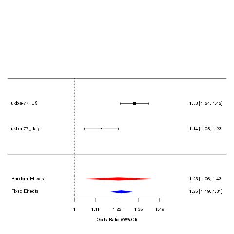

```python
from IPython.display import Image
Image(filename='/data/ALS_50k/SaraSaez_ALS/2021-03-18.COLABORATION_MG/GRS/Results/randomEffectsForestPlot.ukb77.jpeg')
```

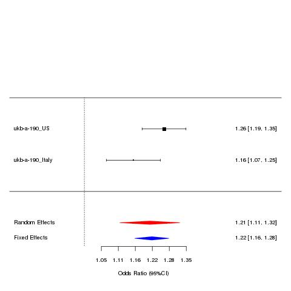

```python
from IPython.display import Image
Image(filename='/data/ALS_50k/SaraSaez_ALS/2021-03-18.COLABORATION_MG/GRS/Results/randomEffectsForestPlot.ukb-a-190.jpeg')
```

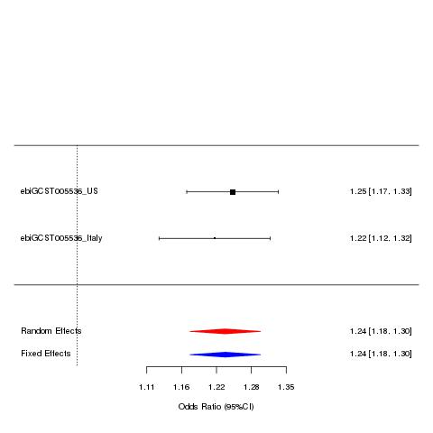

```python
from IPython.display import Image
Image(filename='/data/ALS_50k/SaraSaez_ALS/2021-03-18.COLABORATION_MG/GRS/Results/randomEffectsForestPlot.ebi-a-GCST005536.jpeg')
```

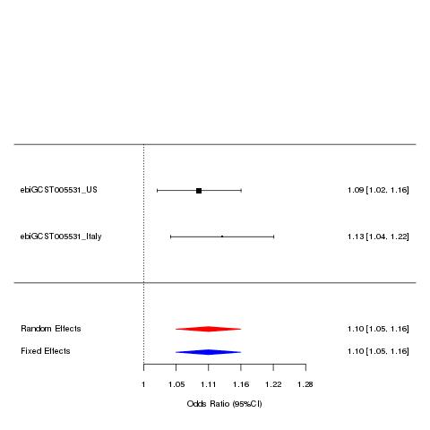

```python
from IPython.display import Image
Image(filename='/data/ALS_50k/SaraSaez_ALS/2021-03-18.COLABORATION_MG/GRS/Results/randomEffectsForestPlot.ebi-a-GCST005531.jpeg')
```

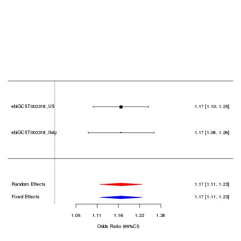

```python
from IPython.display import Image
Image(filename='/data/ALS_50k/SaraSaez_ALS/2021-03-18.COLABORATION_MG/GRS/Results/randomEffectsForestPlot.ebi-a-GCST002318.jpeg')
```

## Final Results

I calculated OR from beta using the formula: OR = exp(beta) CI = beta +/- (1.96*se)

```python
import numpy as np
import pandas as pd
res = pd.read_csv("/data/ALS_50k/SaraSaez_ALS/2021-03-18.COLABORATION_MG/GRS/Results/MG.GRS.METAtableresults.txt",sep="\t")
res
```

|  | Trait | Trait.ID | cohort | OR | OR.CI.lower | OR.CI.upper |
| --- | --- | --- | --- | --- | --- | --- |
| 0 | Rheumatoid arthritis | ebi-a-GCST002318 | US | 1.17 | 1.10 | 1.25 |
| 1 | Rheumatoid arthritis | ebi-a-GCST002318 | Italy | 1.17 | 1.08 | 1.26 |
| 2 | Rheumatoid arthritis | ebi-a-GCST002318 | meta(RE) | 1.17 | 1.11 | 1.23 |
| 3 | Rheumatoid arthritis | ebi-a-GCST002318 | meta(FE) | 1.17 | 1.11 | 1.23 |
| 4 | Multiple sclerosis | ebi-a-GCST005531 | US | 1.09 | 1.02 | 1.16 |
| 5 | Multiple sclerosis | ebi-a-GCST005531 | Italy | 1.13 | 1.04 | 1.22 |
| 6 | Multiple sclerosis | ebi-a-GCST005531 | meta(RE) | 1.10 | 1.05 | 1.16 |
| 7 | Multiple sclerosis | ebi-a-GCST005531 | meta(FE) | 1.10 | 1.05 | 1.16 |
| 8 | Type 1 diabetes | ebi-a-GCST005536 | US | 1.25 | 1.17 | 1.33 |
| 9 | Type 1 diabetes | ebi-a-GCST005536 | Italy | 1.22 | 1.12 | 1.32 |
| 10 | Type 1 diabetes | ebi-a-GCST005536 | meta(RE) | 1.24 | 1.18 | 1.30 |
| 11 | Type 1 diabetes | ebi-a-GCST005536 | meta(FE) | 1.24 | 1.18 | 1.30 |
| 12 | Treatment/medication code: levothyroxine sodium | ukb-a-190 | US | 1.26 | 1.19 | 1.35 |
| 13 | Treatment/medication code: levothyroxine sodium | ukb-a-190 | Italy | 1.16 | 1.07 | 1.25 |
| 14 | Treatment/medication code: levothyroxine sodium | ukb-a-190 | meta(RE) | 1.21 | 1.11 | 1.32 |
| 15 | Treatment/medication code: levothyroxine sodium | ukb-a-190 | meta(FE) | 1.22 | 1.16 | 1.28 |
| 16 | Non-cancer illness code self-reported: hypoth... | ukb-a-77 | US | 1.33 | 1.24 | 1.42 |
| 17 | Non-cancer illness code self-reported: hypoth... | ukb-a-77 | Italy | 1.14 | 1.05 | 1.23 |
| 18 | Non-cancer illness code self-reported: hypoth... | ukb-a-77 | meta(RE) | 1.23 | 1.06 | 1.43 |
| 19 | Non-cancer illness code self-reported: hypoth... | ukb-a-77 | meta(FE) | 1.25 | 1.19 | 1.31 |

```python
%%bash
cd /data/ALS_50k/SaraSaez_ALS/2021-03-18.COLABORATION_MG/Ruth_MGpaper
mkdir GeneticRiskScore
cd /data/ALS_50k/SaraSaez_ALS/2021-03-18.COLABORATION_MG/GRS/Results/
scp MG.GRS.METAtableresults.txt /data/ALS_50k/SaraSaez_ALS/2021-03-18.COLABORATION_MG/Ruth_MGpaper/GeneticRiskScore
```